# Excess Mortality in Europe and Why

*Author: Justin Garza*

**Date:** See below

**Description:**  
This notebook explores excess mortality across Europe, analyzing statistical trends and investigating potential causes through data visualization and interpretation.

**Content Warning:**  
If you find discussions of death or its underlying factors distressing, please proceed with caution or consider whether this content is right for you.

```python
from datetime import datetime
from IPython.display import display
from IPython.display import Markdown as MD
current_date = datetime.now().strftime('%Y-%m-%d')
version = datetime.now().strftime('%Y%m%d.%H%M')
display(MD(f"**Date:** {current_date}"))
display(MD(f"**version:** {version}"))
```

**Date:** 2025-01-07

**version:** 20250107.1921

## Setup

In this section, we prepare the notebook by importing necessary libraries, configuring settings, and setting up directories for data and outputs. The setup ensures the environment is ready for data analysis and visualization.

### Key Setup Steps:

1. **Library Imports**:
   - General-purpose libraries: `os`, `re`, `math`.
   - Data analysis and manipulation: `numpy`, `pandas`.
   - Visualization tools: `matplotlib`, `seaborn`, `plotly`.
   - Statistical tools: `scipy.stats` for correlation metrics.
   - Additional utilities: `pycountry` for country-related metadata and `IPython.display` for rich notebook rendering.
2. **Notebook Display Configuration**:
   - Set pandas options for displaying large datasets without truncation.
   - Configure a color palette for heatmaps using `seaborn`.
3. **Directory Setup**:
   - Define working directories for data input (`data`) and output (`docs`).
   - Check for the existence of these directories, creating the output directory if missing.
4. **Logging**:
   - Print the current working directory (`DIR`) to verify paths.
   - Display a warning if the data folder is missing.

This setup ensures all required dependencies are loaded and configurations are applied before proceeding with analysis.

```python
# this code to will import all the things i need for this notebook

import os
import re
import math

import numpy as np
import pandas as pd

# for the notebook rendering
from IPython.display import display, HTML, FileLink, Markdown
from IPython.display import FileLink as FL
from IPython.display import Markdown as MD


# Graphs and Charts
import matplotlib.pyplot as plt
from matplotlib.colors import Normalize
import seaborn as sns
import plotly.express as px
# use to export plotly graphs
import plotly.io as pio

#misc
from scipy.stats import spearmanr, kendalltau
import pycountry

# pandas Settings/Options
pd.set_option("display.max_rows", None)
pd.set_option("display.max_columns", None)
pd.set_option('display.width', 9000)
pd.set_option('max_colwidth', 400)

# colormap
heatmapCM = sns.color_palette('Spectral_r', as_cmap=True)


## directories
DIR = os.getcwd()
print(f'{DIR=}')

DataDIR = os.path.join(DIR,'data')
OutDIR = os.path.join(DIR,'docs')

if not os.path.exists(DataDIR):
    print('***DATA FOLDER IS MISSING***')

if not os.path.exists(OutDIR):
    os.makedirs(OutDIR)
```

```
DIR='c:\\Users\\JGarza\\GitHub\\Excess_Mortality_And_Vaccines_In_Europe'
```

## Helping Functions

This section defines utility functions that streamline repetitive tasks and improve code readability. These functions will be used throughout the notebook to simplify operations, enhance modularity, and reduce redundancy.

```python
def df_column_uniquify(df):
    '''
    renames columns that are the same
    '''
    df_columns = df.columns
    new_columns = []
    for item in df_columns:
        counter = 0
        newitem = item
        while newitem in new_columns:
            counter += 1
            newitem = "{}_{}".format(item, counter)
        new_columns.append(newitem)
    df.columns = new_columns
    return df
```

```python
def abbr_to_isoalpha3(abbr):
    """
    Convert a European country ISO Alpha-2 code to ISO Alpha-3 code.

    Parameters:
        abbreviation (str): ISO Alpha-2 country code (e.g., 'DE' for Germany).

    Returns:
        str: ISO Alpha-3 country code (e.g., 'DEU'), or None if not found.
    """
    try:
        country = pycountry.countries.get(alpha_2=abbr.upper())
        if country:
            return country.alpha_3
        else:
            return None
    except KeyError:
        return None
```

```python
# this if for converting between the abbreviation andand the names of the countries

country_dict = {
    "BE": "Belgium",
    "BG": "Bulgaria",
    "CZ": "Czechia",
    "DK": "Denmark",
    "DE": "Germany",
    "EE": "Estonia",
    "IE": "Ireland",
    "EL": "Greece",
    "ES": "Spain",
    "FR": "France",
    "HR": "Croatia",
    "IT": "Italy",
    "CY": "Cyprus",
    "LV": "Latvia",
    "LT": "Lithuania",
    "LU": "Luxembourg",
    "HU": "Hungary",
    "MT": "Malta",
    "NL": "Netherlands",
    "AT": "Austria",
    "PL": "Poland",
    "PT": "Portugal",
    "RO": "Romania",
    "SI": "Slovenia",
    "SK": "Slovakia",
    "FI": "Finland",
    "SE": "Sweden",
    "IS": "Iceland",
    "LI": "Liechtenstein",
    "NO": "Norway",
    "CH": "Switzerland",
    "UK": "United Kingdom",
    "ME": "Montenegro",
    "GE": "Georgia",
    "AL": "Albania",
    "RS": "Serbia",
    "AD": "Andorra",
    "AM": "Armenia"
}

def abbr_to_name(abbreviation):
    return country_dict.get(abbreviation.upper(), "Abbreviation not found")

def name_to_abbr(name):
    reverse_dict = {v: k for k, v in country_dict.items()}
    return reverse_dict.get(name.title(), "Country name not found")

# testing
print( abbr_to_name("BE") )  # Output: 'Belgium'
print( name_to_abbr("Belgium") )  # Output: 'BE'
```

```
Belgium
BE
```

## Death Data

In this section, we import and clean the death data to prepare it for analysis.

### Source

- [Eurostat Database](https://ec.europa.eu/eurostat/databrowser/view/demo_r_mwk_ts__custom_14738200/default/table?lang=en)

### Downloading Instructions

1. Visit the [source link](https://ec.europa.eu/eurostat/databrowser/view/demo_r_mwk_ts__custom_14738200/default/table?lang=en).
2. Click "Download" and select the spreadsheet format.
3. Confirm the download to obtain the data.

### Description

This dataset contains the weekly count of deaths in European countries between 2015 and 2024 (up to approximately week 47).

### Variables

- `dd`: Base dataframe for the death data.
- `ddy`: `dd` grouped by year.
- `ddr2023`: Death data ranked by deaths in 2023.
- `ddr2024`: Death data ranked by deaths in 2024.

### Import and Cleaning

This step involves loading the death data and preparing it for analysis by addressing issues such as missing values, inconsistent formatting, and unnecessary columns.

```python
# getting the data
dd = pd.read_excel(os.path.join(DataDIR,"demo_r_mwk_ts__custom_14738200_page_spreadsheet.xlsx"),sheet_name = "Sheet 1")

# remove the headers
dd = dd.iloc[7:47]

# drop the bad columns
for c in dd.columns:
    if pd.isnull(dd.at[7,c]):
        dd = dd.drop(columns=[c])

# rename time columns
for c in dd.columns:
    name = dd.at[7,c]
    dd = dd.rename(columns={c: name})

# make the duplicate column names unique
dd = df_column_uniquify(dd)

# # rename the first two columns
dd = dd.rename(columns={'TIME': 'abbr'})
dd = dd.rename(columns={'TIME_1':'name'})

# drop, replace, reset index,
dd = dd.drop([7,8,9])
dd = dd.replace(to_replace=':', value=None)
dd = dd.reset_index(drop=True)

display(dd)
```

|  | abbr | name | 2015-W01 | 2015-W02 | 2015-W03 | 2015-W04 | 2015-W05 | 2015-W06 | 2015-W07 | 2015-W08 | 2015-W09 | 2015-W10 | 2015-W11 | 2015-W12 | 2015-W13 | 2015-W14 | 2015-W15 | 2015-W16 | 2015-W17 | 2015-W18 | 2015-W19 | 2015-W20 | 2015-W21 | 2015-W22 | 2015-W23 | 2015-W24 | 2015-W25 | 2015-W26 | 2015-W27 | … |
| --- | --- | --- | --- | --- | --- | --- | --- | --- | --- | --- | --- | --- | --- | --- | --- | --- | --- | --- | --- | --- | --- | --- | --- | --- | --- | --- | --- | --- | --- | --- |
| 0 | BE | Belgium | 2461 | 2525 | 2526 | 2510 | 2644 | 2727 | 2892 | 2774 | 2643 | 2457 | 2380 | 2380 | 2270 | 2163 | 2218 | 2152 | 2087 | 2005 | 2063 | 1976 | 1950 | 1905 | 1942 | 2003 | 1900 | 1888 | 2301 | … |
| 1 | BG | Bulgaria | 2501 | 2512 | 2419 | 2339 | 2335 | 2295 | 2341 | 2535 | 2561 | 2469 | 2438 | 2362 | 2374 | 2265 | 2265 | 2242 | 2135 | 2161 | 2106 | 1981 | 1984 | 1837 | 1969 | 1980 | 1904 | 1838 | 1825 | … |
| 2 | CZ | Czechia | 2378 | 2432 | 2396 | 2499 | 2580 | 2598 | 2732 | 2684 | 2609 | 2357 | 2291 | 2273 | 2222 | 2209 | 2111 | 2183 | 2193 | 2041 | 1988 | 1983 | 1993 | 2029 | 1995 | 1886 | 1761 | 1890 | 2050 | … |
| 3 | DK | Denmark | 1127 | 1108 | 1093 | 1068 | 1086 | 1118 | 1106 | 1131 | 1177 | 1210 | 1184 | 1086 | 1093 | 1044 | 1081 | 1052 | 934 | 996 | 978 | 921 | 974 | 977 | 959 | 1017 | 913 | 897 | 942 | … |
| 4 | DE | Germany | 18713 | 19283 | 19500 | 19346 | 20716 | 20905 | 22395 | 23264 | 23598 | 22002 | 20770 | 20009 | 19106 | 18668 | 18089 | 18116 | 17668 | 17114 | 17072 | 16732 | 16330 | 16200 | 16777 | 16272 | 15619 | 16152 | 19252 | … |
| 5 | EE | Estonia | 354 | 340 | 294 | 321 | 329 | 332 | 324 | 332 | 324 | 355 | 341 | 331 | 317 | 304 | 311 | 297 | 302 | 265 | 278 | 333 | 283 | 285 | 289 | 267 | 285 | 239 | 277 | … |
| 6 | IE | Ireland | 632 | 698 | 677 | 654 | 698 | 680 | 684 | 700 | 700 | 694 | 657 | 648 | 641 | 617 | 613 | 580 | 575 | 579 | 565 | 608 | 563 | 563 | 518 | 554 | 533 | 519 | 524 | … |
| 7 | EL | Greece | 2645 | 3013 | 3053 | 3065 | 2778 | 2665 | 2551 | 2690 | 2790 | 2629 | 2547 | 2457 | 2376 | 2390 | 2408 | 2426 | 2240 | 2287 | 2327 | 2015 | 2075 | 1941 | 2090 | 2107 | 2235 | 1922 | 1917 | … |
| 8 | ES | Spain | 9605 | 10415 | 10738 | 10625 | 11046 | 10682 | 10857 | 10580 | 10058 | 9421 | 8785 | 8379 | 8366 | 8282 | 7894 | 7855 | 7802 | 7365 | 7464 | 7543 | 7234 | 7096 | 7364 | 7152 | 6956 | 7111 | 8146 | … |
| 9 | FR | France | 12986 | 13364 | 13006 | 12830 | 13497 | 14185 | 14913 | 14550 | 13820 | 13153 | 12511 | 12114 | 11905 | 11361 | 11453 | 11094 | 10986 | 10798 | 10702 | 10331 | 10222 | 10339 | 10643 | 10385 | 10095 | 10409 | 11412 | … |
| 10 | HR | Croatia | 1177 | 1254 | 1276 | 1231 | 1215 | 1287 | 1306 | 1301 | 1239 | 1215 | 1208 | 1232 | 1085 | 1137 | 1078 | 1026 | 1041 | 1019 | 1011 | 926 | 947 | 855 | 998 | 1000 | 875 | 880 | 996 | … |
| 11 | IT | Italy | 15178 | 15811 | 15480 | 14922 | 15228 | 15640 | 15510 | 15149 | 14544 | 14211 | 13846 | 13455 | 13126 | 12832 | 12811 | 12781 | 12046 | 11946 | 12177 | 11518 | 11058 | 10848 | 12060 | 11447 | 10591 | 10808 | 11819 | … |
| 12 | CY | Cyprus | 126 | 137 | 155 | 154 | 145 | 157 | 134 | 129 | 143 | 141 | 151 | 119 | 108 | 112 | 122 | 113 | 128 | 118 | 106 | 92 | 95 | 86 | 93 | 103 | 98 | 117 | 81 | … |
| 13 | LV | Latvia | 617 | 608 | 622 | 618 | 624 | 573 | 623 | 596 | 607 | 605 | 600 | 565 | 555 | 565 | 600 | 570 | 580 | 516 | 513 | 547 | 535 | 535 | 521 | 459 | 549 | 523 | 584 | … |
| 14 | LT | Lithuania | 844 | 827 | 905 | 853 | 881 | 873 | 921 | 918 | 922 | 911 | 896 | 909 | 859 | 849 | 867 | 890 | 791 | 783 | 796 | 763 | 802 | 780 | 850 | 740 | 749 | 691 | 827 | … |
| 15 | LU | Luxembourg | 81 | 87 | 80 | 94 | 100 | 100 | 92 | 115 | 88 | 112 | 84 | 73 | 88 | 91 | 75 | 80 | 72 | 61 | 68 | 65 | 62 | 77 | 71 | 65 | 76 | 54 | 87 | … |
| 16 | HU | Hungary | 2800 | 3005 | 2900 | 3005 | 3067 | 3350 | 3280 | 3349 | 3120 | 2962 | 2777 | 2764 | 2690 | 2639 | 2612 | 2612 | 2598 | 2467 | 2420 | 2293 | 2274 | 2177 | 2434 | 2298 | 2067 | 2141 | 2383 | … |
| 17 | MT | Malta | 85 | 93 | 93 | 72 | 84 | 78 | 93 | 100 | 95 | 75 | 95 | 81 | 76 | 69 | 74 | 65 | 56 | 63 | 54 | 49 | 69 | 54 | 61 | 66 | 50 | 50 | 53 | … |
| 18 | NL | Netherlands | 3255 | 3429 | 3377 | 3353 | 3322 | 3272 | 3311 | 3381 | 3207 | 3222 | 3086 | 3052 | 3084 | 2839 | 2888 | 2893 | 2829 | 2674 | 2741 | 2721 | 2566 | 2660 | 2595 | 2680 | 2559 | 2547 | 2848 | … |
| 19 | AT | Austria | 1704 | 1768 | 1837 | 1792 | 1837 | 1926 | 1992 | 2020 | 1883 | 1846 | 1763 | 1696 | 1725 | 1604 | 1563 | 1614 | 1547 | 1453 | 1452 | 1461 | 1396 | 1304 | 1437 | 1502 | 1285 | 1374 | 1487 | … |
| 20 | PL | Poland | 7984 | 7754 | 7800 | 7559 | 7963 | 8166 | 8873 | 8985 | 9068 | 8839 | 8850 | 8640 | 8535 | 8449 | 8154 | 7974 | 7797 | 7483 | 7324 | 7266 | 7102 | 7015 | 7387 | 7076 | 6737 | 6781 | 7360 | … |
| 21 | PT | Portugal | 2813 | 3054 | 3167 | 3088 | 2909 | 2869 | 2977 | 2684 | 2699 | 2447 | 2314 | 2284 | 2083 | 2179 | 1933 | 1937 | 1816 | 1819 | 1941 | 1911 | 1791 | 1950 | 1847 | 1799 | 1845 | 1727 | 1697 | … |
| 22 | RO | Romania | 5803 | 5848 | 5602 | 5508 | 5560 | 5688 | 5815 | 6281 | 6139 | 5909 | 5824 | 5844 | 5865 | 5432 | 5425 | 5571 | 5282 | 5053 | 4822 | 4667 | 4769 | 4306 | 4913 | 4682 | 4410 | 4283 | 4434 | … |
| 23 | SI | Slovenia | 408 | 407 | 453 | 449 | 432 | 420 | 459 | 446 | 449 | 384 | 453 | 417 | 460 | 444 | 423 | 420 | 388 | 387 | 362 | 327 | 318 | 333 | 364 | 325 | 323 | 310 | 384 | … |
| 24 | SK | Slovakia | 1112 | 1187 | 1210 | 1235 | 1292 | 1226 | 1275 | 1266 | 1235 | 1164 | 1186 | 1102 | 1088 | 1037 | 1090 | 1078 | 1062 | 980 | 958 | 915 | 975 | 926 | 1017 | 1004 | 910 | 911 | 1007 | … |
| 25 | FI | Finland | 1083 | 1158 | 1151 | 1040 | 1062 | 1061 | 1094 | 1073 | 1126 | 1134 | 1046 | 1015 | 1013 | 1070 | 1075 | 1039 | 1074 | 1021 | 1009 | 927 | 939 | 947 | 908 | 928 | 987 | 923 | 1016 | … |
| 26 | SE | Sweden | 1927 | 1966 | 1935 | 1946 | 1975 | 1868 | 2001 | 2107 | 2076 | 2041 | 1932 | 1874 | 1930 | 1834 | 1849 | 1844 | 1764 | 1656 | 1661 | 1668 | 1670 | 1627 | 1617 | 1609 | 1592 | 1525 | 1674 | … |
| 27 | IS | Iceland | 49 | 42 | 44 | 48 | 44 | 57 | 50 | 47 | 47 | 41 | 46 | 45 | 42 | 41 | 39 | 47 | 41 | 41 | 37 | 53 | 50 | 39 | 37 | 41 | 32 | 32 | 42 | … |
| 28 | LI | Liechtenstein | 12 | 4 | 4 | 4 | 6 | 5 | 6 | 4 | 6 | 12 | 7 | 5 | 5 | 5 | 2 | 2 | 5 | 5 | 4 | 3 | 3 | 3 | 8 | 4 | 4 | 3 | 4 | … |
| 29 | NO | Norway | 938 | 977 | 913 | 930 | 911 | 898 | 866 | 931 | 925 | 976 | 836 | 785 | 795 | 786 | 795 | 777 | 749 | 686 | 729 | 707 | 780 | 716 | 758 | 746 | 712 | 752 | 721 | … |
| 30 | CH | Switzerland | 1423 | 1494 | 1524 | 1480 | 1590 | 1656 | 1805 | 1772 | 1729 | 1549 | 1541 | 1435 | 1293 | 1302 | 1229 | 1284 | 1215 | 1275 | 1161 | 1152 | 1129 | 1099 | 1171 | 1169 | 1100 | 1197 | 1295 | … |
| 31 | UK | United Kingdom | 12559 | 18270 | 16703 | 15688 | 14536 | 13701 | 13486 | 13038 | 13154 | 12998 | 12454 | 12010 | 11969 | 10294 | 11553 | 13027 | 11988 | 11560 | 10099 | 11659 | 11305 | 9495 | 11576 | 10823 | 10613 | 10488 | 10514 | … |
| 32 | ME | Montenegro | 142 | 140 | 148 | 128 | 134 | 141 | 126 | 162 | 155 | 163 | 122 | 140 | 106 | 137 | 114 | 121 | 138 | 108 | 98 | 123 | 98 | 114 | 125 | 116 | 89 | 89 | 102 | … |
| 33 | GE | Georgia | 1011 | 1036 | 1038 | 1026 | 991 | 994 | 1048 | 1078 | 1084 | 1115 | 1095 | 1034 | 1053 | 1000 | 986 | 1060 | 1012 | 996 | 912 | 998 | 983 | 921 | 867 | 864 | 865 | 894 | 793 | … |
| 34 | AL | Albania | 331 | 584 | 493 | 635 | 542 | 530 | 489 | 534 | 581 | 479 | 444 | 460 | 460 | 417 | 446 | 454 | 477 | 400 | 415 | 377 | 395 | 352 | 396 | 349 | 373 | 347 | 363 | … |
| 35 | RS | Serbia | 2338 | 2450 | 2238 | 2249 | 2210 | 2183 | 2339 | 2377 | 2405 | 2266 | 2180 | 2186 | 2219 | 2131 | 2060 | 2239 | 2103 | 2058 | 1945 | 1855 | 1840 | 1719 | 1994 | 1857 | 1679 | 1715 | 1817 | … |
| 36 | AD | Andorra | 3 | 5 | 6 | 5 | 6 | 10 | 1 | 6 | 6 | 7 | 8 | 9 | 4 | 3 | 5 | 8 | 7 | 7 | 5 | 3 | 7 | 8 | 2 | 1 | 3 | 8 | 8 | … |

```python
# This code processes the raw death data (dd) by restructuring it into a long-form dataframe.
# Each row in the new dataframe represents a single country's deaths for a specific year and week,
# along with additional metadata such as country abbreviations and derived values.

yw_cols = dd.columns[2::]
abbrs = dd.abbr.drop_duplicates().to_list()
names = dd.name.drop_duplicates().to_list()
d = []

for ic,c in enumerate(abbrs):
    for yw in yw_cols:
        y = yw[0:4]
        w = yw[6:8]
        dv = dd.at[ic,yw]

        d.append(
            {
                'name': names[ic],
                'abbr':c,
                'year':y,
                'week':w,
                'year.week': int(y) + int(w)/100,
                'year.p': int(y) + (int(w)/53.001),
                'deaths': dv
            }
        )

#print(d)
dd = pd.DataFrame(d)
dd.year = pd.to_numeric(dd.year)
dd.week = pd.to_numeric(dd.week)
display(dd.head(10))
display(dd.tail(10))
```

|  | name | abbr | year | week | year.week | year.p | deaths |
| --- | --- | --- | --- | --- | --- | --- | --- |
| 0 | Belgium | BE | 2015 | 1 | 2015.01 | 2015.018868 | 2461.0 |
| 1 | Belgium | BE | 2015 | 2 | 2015.02 | 2015.037735 | 2525.0 |
| 2 | Belgium | BE | 2015 | 3 | 2015.03 | 2015.056603 | 2526.0 |
| 3 | Belgium | BE | 2015 | 4 | 2015.04 | 2015.075470 | 2510.0 |
| 4 | Belgium | BE | 2015 | 5 | 2015.05 | 2015.094338 | 2644.0 |
| 5 | Belgium | BE | 2015 | 6 | 2015.06 | 2015.113205 | 2727.0 |
| 6 | Belgium | BE | 2015 | 7 | 2015.07 | 2015.132073 | 2892.0 |
| 7 | Belgium | BE | 2015 | 8 | 2015.08 | 2015.150941 | 2774.0 |
| 8 | Belgium | BE | 2015 | 9 | 2015.09 | 2015.169808 | 2643.0 |
| 9 | Belgium | BE | 2015 | 10 | 2015.10 | 2015.188676 | 2457.0 |

|  | name | abbr | year | week | year.week | year.p | deaths |
| --- | --- | --- | --- | --- | --- | --- | --- |
| 19119 | Andorra | AD | 2024 | 38 | 2024.38 | 2024.716968 | NaN |
| 19120 | Andorra | AD | 2024 | 39 | 2024.39 | 2024.735835 | NaN |
| 19121 | Andorra | AD | 2024 | 40 | 2024.40 | 2024.754703 | NaN |
| 19122 | Andorra | AD | 2024 | 41 | 2024.41 | 2024.773570 | NaN |
| 19123 | Andorra | AD | 2024 | 42 | 2024.42 | 2024.792438 | NaN |
| 19124 | Andorra | AD | 2024 | 43 | 2024.43 | 2024.811305 | NaN |
| 19125 | Andorra | AD | 2024 | 44 | 2024.44 | 2024.830173 | NaN |
| 19126 | Andorra | AD | 2024 | 45 | 2024.45 | 2024.849041 | NaN |
| 19127 | Andorra | AD | 2024 | 46 | 2024.46 | 2024.867908 | NaN |
| 19128 | Andorra | AD | 2024 | 47 | 2024.47 | 2024.886776 | NaN |

```python
# here we are just looking at some statistics about the data
col = 'deaths'
display(MD(f'### describe {col=}'))
display(dd[col].describe())
display(MD(f'### Nan {col=}'))
display(dd[col].isna().sum())
```

describe col='deaths'

```
count    18204.000000
mean      2975.750989
std       4375.910501
min          0.000000
25%        459.000000
50%       1233.500000
75%       2552.000000
max      28682.000000
Name: deaths, dtype: float64
```

Nan col='deaths'

```
np.int64(925)
```

```python
# there are quite a few NAN (not a number) values
# here we get rid of them

# Get counts of NA values for each 'abbr' group
na_counts = dd[dd.deaths.isna()].groupby('abbr').size()

# Filter for 'abbr' groups with more than 12 NA values
filtered_abbrs = na_counts[na_counts > 12].index

for c in filtered_abbrs:
    print(f'removing -- {c} {abbr_to_name(c)} NACount={na_counts[c]}')
    dd = dd[dd.abbr != c]  # Drop rows where 'abbr' matches
```

```
removing -- AD Andorra NACount=256
removing -- AL Albania NACount=166
removing -- GE Georgia NACount=203
removing -- UK United Kingdom NACount=205
```

```python
# Fill missing values (NaNs) in the 2024 data with the mean deaths for 2024 by country

# Filter data for the year 2024
df_2024 = dd[dd.year == 2024]

# Group the 2024 data by country abbreviation ('abbr') and calculate summary statistics
grouped = df_2024.groupby('abbr')

# Compute statistics: mean, total count, number of NaNs, total deaths, and mean deaths per week
stats = grouped['deaths'].agg(
    Mean='mean',          # Average deaths for each country in 2024
    Count='size',         # Total number of records for each country in 2024
    NACount=lambda x: x.isna().sum(),  # Count of missing (NaN) values
    SumFor2024='sum'      # Total deaths for each country in 2024
).reset_index()

# Replace missing death values in 2024 with the calculated mean for each country
for _, row in stats.iterrows():
    dd.loc[
        (dd.abbr == row['abbr']) & (dd.year == 2024) & (dd.deaths.isna()),
        'deaths'
    ] = row['Mean']
```

```python
# here we normalize the death values

dd['deaths_norm'] = 0.0

## baseline years are 2015,2016,2017 before the pandemic
blyears = dd[dd.year.isin([2015,2016,2017])]
grouped = blyears.groupby('abbr')

temp = grouped['deaths'].agg(
    baseline='mean',
).reset_index()

for _, row in temp.iterrows():
    dd.loc[dd.abbr == row['abbr'], 'deaths_norm'] = dd[(dd.abbr == row['abbr'])].deaths / row['baseline']
```

```python
display(dd.head(10))
display(dd.tail(10))
```

|  | name | abbr | year | week | year.week | year.p | deaths | deaths_norm |
| --- | --- | --- | --- | --- | --- | --- | --- | --- |
| 0 | Belgium | BE | 2015 | 1 | 2015.01 | 2015.018868 | 2461.0 | 1.173617 |
| 1 | Belgium | BE | 2015 | 2 | 2015.02 | 2015.037735 | 2525.0 | 1.204138 |
| 2 | Belgium | BE | 2015 | 3 | 2015.03 | 2015.056603 | 2526.0 | 1.204615 |
| 3 | Belgium | BE | 2015 | 4 | 2015.04 | 2015.075470 | 2510.0 | 1.196984 |
| 4 | Belgium | BE | 2015 | 5 | 2015.05 | 2015.094338 | 2644.0 | 1.260887 |
| 5 | Belgium | BE | 2015 | 6 | 2015.06 | 2015.113205 | 2727.0 | 1.300469 |
| 6 | Belgium | BE | 2015 | 7 | 2015.07 | 2015.132073 | 2892.0 | 1.379155 |
| 7 | Belgium | BE | 2015 | 8 | 2015.08 | 2015.150941 | 2774.0 | 1.322882 |
| 8 | Belgium | BE | 2015 | 9 | 2015.09 | 2015.169808 | 2643.0 | 1.260410 |
| 9 | Belgium | BE | 2015 | 10 | 2015.10 | 2015.188676 | 2457.0 | 1.171709 |

|  | name | abbr | year | week | year.week | year.p | deaths | deaths_norm |
| --- | --- | --- | --- | --- | --- | --- | --- | --- |
| 18602 | Serbia | RS | 2024 | 38 | 2024.38 | 2024.716968 | 1693.000000 | 0.859978 |
| 18603 | Serbia | RS | 2024 | 39 | 2024.39 | 2024.735835 | 1809.000000 | 0.918901 |
| 18604 | Serbia | RS | 2024 | 40 | 2024.40 | 2024.754703 | 1815.000000 | 0.921949 |
| 18605 | Serbia | RS | 2024 | 41 | 2024.41 | 2024.773570 | 1825.000000 | 0.927028 |
| 18606 | Serbia | RS | 2024 | 42 | 2024.42 | 2024.792438 | 1743.000000 | 0.885376 |
| 18607 | Serbia | RS | 2024 | 43 | 2024.43 | 2024.811305 | 1843.000000 | 0.936172 |
| 18608 | Serbia | RS | 2024 | 44 | 2024.44 | 2024.830173 | 1821.860465 | 0.925434 |
| 18609 | Serbia | RS | 2024 | 45 | 2024.45 | 2024.849041 | 1821.860465 | 0.925434 |
| 18610 | Serbia | RS | 2024 | 46 | 2024.46 | 2024.867908 | 1821.860465 | 0.925434 |
| 18611 | Serbia | RS | 2024 | 47 | 2024.47 | 2024.886776 | 1821.860465 | 0.925434 |

```python
# here we are making ddy (the death data grouped by year)

ddy = dd.groupby(
    ['name', 'abbr', 'year'],
    as_index=False)\
    [['deaths', 'deaths_norm']]\
    .mean()

display(ddy.head(10))
display(ddy.tail(10))
```

|  | name | abbr | year | deaths | deaths_norm |
| --- | --- | --- | --- | --- | --- |
| 0 | Austria | AT | 2015 | 1565.452830 | 1.010917 |
| 1 | Austria | AT | 2016 | 1516.192308 | 0.979106 |
| 2 | Austria | AT | 2017 | 1563.673077 | 1.009767 |
| 3 | Austria | AT | 2018 | 1578.134615 | 1.019106 |
| 4 | Austria | AT | 2019 | 1568.403846 | 1.012822 |
| 5 | Austria | AT | 2020 | 1720.679245 | 1.111157 |
| 6 | Austria | AT | 2021 | 1721.884615 | 1.111935 |
| 7 | Austria | AT | 2022 | 1761.096154 | 1.137257 |
| 8 | Austria | AT | 2023 | 1685.923077 | 1.088712 |
| 9 | Austria | AT | 2024 | 1652.955556 | 1.067423 |

|  | name | abbr | year | deaths | deaths_norm |
| --- | --- | --- | --- | --- | --- |
| 320 | Switzerland | CH | 2015 | 1297.849057 | 1.018109 |
| 321 | Switzerland | CH | 2016 | 1243.250000 | 0.975278 |
| 322 | Switzerland | CH | 2017 | 1282.750000 | 1.006264 |
| 323 | Switzerland | CH | 2018 | 1286.307692 | 1.009055 |
| 324 | Switzerland | CH | 2019 | 1298.365385 | 1.018514 |
| 325 | Switzerland | CH | 2020 | 1431.339623 | 1.122827 |
| 326 | Switzerland | CH | 2021 | 1357.673077 | 1.065038 |
| 327 | Switzerland | CH | 2022 | 1424.903846 | 1.117778 |
| 328 | Switzerland | CH | 2023 | 1371.692308 | 1.076036 |
| 329 | Switzerland | CH | 2024 | 1331.238095 | 1.044301 |

### Viewing the Death Data

This section focuses on exploring the death data to ensure it is correctly loaded and processed. We will inspect the data's structure, check for anomalies, and visualize key trends.

```python
title = 'Line Chart - normalized deaths in Europe 2015-2024 (by year)'
display(MD(f'### {title}'))
report = r"docs\ddy_line.html"

fig = px.line(
    ddy,
    x='year',
    y='deaths_norm',
    color='abbr',
    height=750 ,
    title=title
    )
fig.update_layout(template="plotly_dark")
pio.write_html(fig, file=report, auto_open=True)

display(FileLink(report))
display(MD('[weblink](https://jgarza9788.github.io/Excess_Mortality_And_Vaccines_In_Europe/ddy_line.html)'))

fig.show()
```

Line Chart - normalized deaths in Europe 2015-2024 (by year)

docs\ddy_line.html

[weblink](https://jgarza9788.github.io/Excess_Mortality_And_Vaccines_In_Europe/ddy_line.html)

```python
title = 'Line Chart - normalized deaths in Europe 2015-2024 (by week)'
display(MD(f'### {title}'))
report = r"docs\dd_line.html"

fig = px.line(
    dd,
    x='year.p',
    y='deaths_norm',
    color='abbr',
    height=750 ,
    title=title
    )
fig.update_layout(template="plotly_dark")
pio.write_html(fig, file=report, auto_open=True)

display(FileLink(report))
display(MD('[weblink](https://jgarza9788.github.io/Excess_Mortality_And_Vaccines_In_Europe/dd_line.html)'))

fig.show()
```

Line Chart - normalized deaths in Europe 2015-2024 (by week)

docs\dd_line.html

[weblink](https://jgarza9788.github.io/Excess_Mortality_And_Vaccines_In_Europe/dd_line.html)

```python
display(MD('### HeatMap (based on Year)'))
temp = pd.pivot_table(
    data = ddy.copy(),
    values = 'deaths_norm',
    index = ['abbr','name'],
    columns=['year'],
    aggfunc='mean',
)
temp.columns.name = 'index'

temp = temp.sort_values(by=2023,ascending=False)
temp = temp.reset_index()
ddr2023 = temp.copy()

temp = temp.sort_values(by=2024,ascending=False)
temp = temp.reset_index(drop=True)
ddr2024 = temp.copy()

display(temp.style.background_gradient(cmap=heatmapCM,axis=1))
```

HeatMap (based on Year)

| index | abbr | name | 2015 | 2016 | 2017 | 2018 | 2019 | 2020 | 2021 | 2022 | 2023 | 2024 |
| --- | --- | --- | --- | --- | --- | --- | --- | --- | --- | --- | --- | --- |
| 0 | MT | Malta | 1.004157 | 0.961827 | 1.033935 | 1.067663 | 1.071152 | 1.184449 | 1.203738 | 1.226999 | 1.169429 | 1.195514 |
| 1 | IS | Iceland | 0.975717 | 1.026691 | 0.998060 | 1.006559 | 1.012375 | 1.029265 | 1.045927 | 1.203398 | 1.147478 | 1.163664 |
| 2 | NL | Netherlands | 0.990752 | 0.999534 | 1.009892 | 1.031217 | 1.021614 | 1.133312 | 1.147735 | 1.140822 | 1.138502 | 1.149227 |
| 3 | LI | Liechtenstein | 0.984876 | 1.050506 | 0.964909 | 1.062178 | 1.011598 | 1.240639 | 1.038833 | 1.085522 | 1.027161 | 1.127824 |
| 4 | IE | Ireland | 0.994335 | 1.004840 | 1.000934 | 1.020105 | 1.008454 | 1.028312 | 1.105698 | 1.135294 | 1.132809 | 1.113159 |
| 5 | CY | Cyprus | 1.016240 | 0.943163 | 1.040284 | 1.003756 | 1.076467 | 1.129533 | 1.249761 | 1.247856 | 1.157833 | 1.095931 |
| 6 | LU | Luxembourg | 0.979597 | 0.972290 | 1.048505 | 1.060591 | 1.057631 | 1.129392 | 1.107454 | 1.096108 | 1.088462 | 1.086108 |
| 7 | DE | Germany | 1.003695 | 0.985588 | 1.010646 | 1.035597 | 1.018716 | 1.068455 | 1.108186 | 1.157326 | 1.114018 | 1.077843 |
| 8 | PT | Portugal | 0.993463 | 1.006740 | 0.999923 | 1.031115 | 1.019970 | 1.125985 | 1.136183 | 1.134645 | 1.078520 | 1.074541 |
| 9 | FI | Finland | 0.983845 | 1.009937 | 1.006529 | 1.023471 | 1.011123 | 1.038642 | 1.083859 | 1.163166 | 1.150723 | 1.071371 |
| 10 | NO | Norway | 1.003358 | 0.995838 | 1.000739 | 1.003004 | 0.997833 | 0.995627 | 1.032626 | 1.122701 | 1.072443 | 1.069332 |
| 11 | AT | Austria | 1.010917 | 0.979106 | 1.009767 | 1.019106 | 1.012822 | 1.111157 | 1.111935 | 1.137257 | 1.088712 | 1.067423 |
| 12 | DK | Denmark | 0.994781 | 0.997707 | 1.007612 | 1.045049 | 1.020932 | 1.032815 | 1.082334 | 1.124705 | 1.097761 | 1.065182 |
| 13 | SI | Slovenia | 0.993245 | 0.981901 | 1.024985 | 1.024583 | 1.030552 | 1.200958 | 1.158048 | 1.125547 | 1.076946 | 1.062972 |
| 14 | FR | France | 0.994928 | 0.991452 | 1.013718 | 1.019894 | 1.025786 | 1.117518 | 1.106247 | 1.129496 | 1.068420 | 1.054981 |
| 15 | ES | Spain | 1.010234 | 0.977384 | 1.012185 | 1.020380 | 0.998528 | 1.177890 | 1.077604 | 1.108187 | 1.046356 | 1.045272 |
| 16 | CH | Switzerland | 1.018109 | 0.975278 | 1.006264 | 1.009055 | 1.018514 | 1.122827 | 1.065038 | 1.117778 | 1.076036 | 1.044301 |
| 17 | EL | Greece | 0.999478 | 0.975679 | 1.024853 | 0.990845 | 1.028727 | 1.077646 | 1.186747 | 1.158860 | 1.054607 | 1.035743 |
| 18 | EE | Estonia | 0.991092 | 0.999254 | 1.009825 | 1.023397 | 1.000429 | 1.027967 | 1.201663 | 1.122383 | 1.040950 | 1.032921 |
| 19 | PL | Poland | 0.999206 | 0.980662 | 1.020147 | 1.042396 | 1.033049 | 1.207455 | 1.314551 | 1.132975 | 1.033751 | 1.014324 |
| 20 | BE | Belgium | 1.011440 | 0.986164 | 1.002176 | 1.011925 | 0.994454 | 1.155612 | 1.026736 | 1.065089 | 1.019482 | 1.010644 |
| 21 | ME | Montenegro | 0.986453 | 1.001060 | 1.012747 | 1.009631 | 1.025214 | 1.123749 | 1.420402 | 1.095026 | 0.983919 | 1.006421 |
| 22 | CZ | Czechia | 1.011566 | 0.976933 | 1.011278 | 1.025827 | 1.020689 | 1.175313 | 1.267662 | 1.091829 | 1.023413 | 1.003266 |
| 23 | SK | Slovakia | 1.010223 | 0.979585 | 1.009996 | 1.018177 | 0.998956 | 1.112044 | 1.372265 | 1.116390 | 1.014717 | 0.997733 |
| 24 | IT | Italy | 1.015460 | 0.966445 | 1.017797 | 0.989897 | 0.996219 | 1.150568 | 1.094275 | 1.102056 | 1.020140 | 0.987198 |
| 25 | SE | Sweden | 1.006504 | 0.991896 | 1.001474 | 1.001597 | 0.962637 | 1.065523 | 0.992098 | 1.018030 | 1.012161 | 0.966534 |
| 26 | HU | Hungary | 1.013572 | 0.973807 | 1.012360 | 1.007202 | 0.996800 | 1.083611 | 1.195559 | 1.048346 | 0.985011 | 0.965450 |
| 27 | HR | Croatia | 1.023025 | 0.969214 | 1.007318 | 0.993949 | 0.975965 | 1.074993 | 1.184562 | 1.076756 | 0.968855 | 0.956459 |
| 28 | RS | Serbia | 1.011781 | 0.980472 | 1.007521 | 0.986724 | 0.985532 | 1.140947 | 1.326833 | 1.019927 | 0.923248 | 0.925434 |
| 29 | LT | Lithuania | 1.021154 | 0.999852 | 0.978587 | 0.965422 | 0.934393 | 1.064130 | 1.161457 | 1.037072 | 0.925045 | 0.917770 |
| 30 | LV | Latvia | 0.997081 | 0.997699 | 1.005276 | 1.008223 | 0.969252 | 1.009608 | 1.209145 | 1.062066 | 0.968761 | 0.914908 |
| 31 | BG | Bulgaria | 1.011131 | 0.983808 | 1.004848 | 0.994599 | 0.991014 | 1.135539 | 1.366352 | 1.086958 | 0.925228 | 0.904553 |
| 32 | RO | Romania | 1.007747 | 0.988011 | 1.004094 | 1.011801 | 1.000319 | 1.136796 | 1.284457 | 1.038581 | 0.923994 | 0.825940 |

```python
display(MD('### HeatMap (by week)'))
temp = pd.pivot_table(
    data = dd.copy(),
    values = 'deaths_norm',
    index = ['abbr','name'],
    columns=['year.p'],
    aggfunc='mean',
)
temp.columns.name = 'index'
temp = temp.reset_index()
temp = temp.set_index('name').reindex(ddr2024['name']).reset_index()
display(temp.style.background_gradient(cmap=heatmapCM,axis=1))
```

HeatMap (by week)

| index | name | abbr | 2015.018868 | 2015.037735 | 2015.056603 | 2015.075470 | 2015.094338 | 2015.113205 | 2015.132073 | 2015.150941 | 2015.169808 | 2015.188676 | 2015.207543 | 2015.226411 | 2015.245278 | 2015.264146 | 2015.283014 | 2015.301881 | 2015.320749 | 2015.339616 | 2015.358484 | 2015.377351 | 2015.396219 | 2015.415087 | 2015.433954 | 2015.452822 | 2015.471689 | 2015.490557 | 2015.509424 | … |
| --- | --- | --- | --- | --- | --- | --- | --- | --- | --- | --- | --- | --- | --- | --- | --- | --- | --- | --- | --- | --- | --- | --- | --- | --- | --- | --- | --- | --- | --- | --- |
| 0 | Malta | MT | 1.285150 | 1.406106 | 1.406106 | 1.088598 | 1.270031 | 1.179314 | 1.406106 | 1.511941 | 1.436344 | 1.133956 | 1.436344 | 1.224673 | 1.149076 | 1.043240 | 1.118837 | 0.982762 | 0.846687 | 0.952523 | 0.816448 | 0.740851 | 1.043240 | 0.816448 | 0.922284 | 0.997881 | 0.755971 | 0.755971 | 0.801329 | … |
| 1 | Iceland | IS | 1.139873 | 0.977034 | 1.023559 | 1.116610 | 1.023559 | 1.325974 | 1.163135 | 1.093347 | 1.093347 | 0.953771 | 1.070084 | 1.046822 | 0.977034 | 0.953771 | 0.907246 | 1.093347 | 0.953771 | 0.953771 | 0.860720 | 1.232923 | 1.163135 | 0.907246 | 0.860720 | 0.953771 | 0.744407 | 0.744407 | 0.977034 | … |
| 2 | Netherlands | NL | 1.141503 | 1.202524 | 1.184288 | 1.175871 | 1.165000 | 1.147465 | 1.161142 | 1.185690 | 1.124670 | 1.129930 | 1.082236 | 1.070313 | 1.081535 | 0.995615 | 1.012799 | 1.014553 | 0.992108 | 0.937751 | 0.961247 | 0.954234 | 0.899876 | 0.932841 | 0.910046 | 0.939855 | 0.897421 | 0.893213 | 0.998771 | … |
| 3 | Liechtenstein | LI | 2.427835 | 0.809278 | 0.809278 | 0.809278 | 1.213918 | 1.011598 | 1.213918 | 0.809278 | 1.213918 | 2.427835 | 1.416237 | 1.011598 | 1.011598 | 1.011598 | 0.404639 | 0.404639 | 1.011598 | 1.011598 | 0.809278 | 0.606959 | 0.606959 | 0.606959 | 1.618557 | 0.809278 | 0.809278 | 0.606959 | 0.809278 | … |
| 4 | Ireland | IE | 1.060675 | 1.171441 | 1.136197 | 1.097597 | 1.171441 | 1.141232 | 1.147945 | 1.174798 | 1.174798 | 1.164728 | 1.102632 | 1.087527 | 1.075779 | 1.035500 | 1.028787 | 0.973404 | 0.965013 | 0.971726 | 0.948230 | 1.020396 | 0.944873 | 0.944873 | 0.869350 | 0.929769 | 0.894525 | 0.871029 | 0.879420 | … |
| 5 | Cyprus | CY | 1.134289 | 1.233314 | 1.395356 | 1.386353 | 1.305333 | 1.413360 | 1.206307 | 1.161296 | 1.287328 | 1.269323 | 1.359346 | 1.071273 | 0.972248 | 1.008257 | 1.098280 | 1.017259 | 1.152294 | 1.062271 | 0.954243 | 0.828211 | 0.855218 | 0.774197 | 0.837213 | 0.927236 | 0.882225 | 1.053268 | 0.729186 | … |
| 6 | Luxembourg | LU | 1.038886 | 1.115840 | 1.026060 | 1.205620 | 1.282575 | 1.282575 | 1.179969 | 1.474961 | 1.128666 | 1.436484 | 1.077363 | 0.936280 | 1.128666 | 1.167143 | 0.961931 | 1.026060 | 0.923454 | 0.782371 | 0.872151 | 0.833674 | 0.795196 | 0.987583 | 0.910628 | 0.833674 | 0.974757 | 0.692590 | 1.115840 | … |
| 7 | Germany | DE | 1.058196 | 1.090429 | 1.102700 | 1.093991 | 1.171463 | 1.182151 | 1.266408 | 1.315549 | 1.334436 | 1.244184 | 1.174516 | 1.131483 | 1.080419 | 1.055651 | 1.022909 | 1.024436 | 0.999102 | 0.967774 | 0.965399 | 0.946173 | 0.923440 | 0.916089 | 0.948718 | 0.920160 | 0.883234 | 0.913375 | 1.088676 | … |
| 8 | Portugal | PT | 1.338403 | 1.453069 | 1.506834 | 1.469246 | 1.384079 | 1.365048 | 1.416433 | 1.277026 | 1.284163 | 1.164263 | 1.100983 | 1.086709 | 0.991075 | 1.036751 | 0.919706 | 0.921609 | 0.864039 | 0.865466 | 0.923513 | 0.909239 | 0.852144 | 0.927795 | 0.878788 | 0.855950 | 0.877837 | 0.821693 | 0.807419 | … |
| 9 | Finland | FI | 1.060103 | 1.133517 | 1.126665 | 1.018012 | 1.039547 | 1.038568 | 1.070871 | 1.050315 | 1.102194 | 1.110025 | 1.023885 | 0.993541 | 0.991583 | 1.047378 | 1.052272 | 1.017033 | 1.051293 | 0.999414 | 0.987668 | 0.907401 | 0.919148 | 0.926978 | 0.888803 | 0.908380 | 0.966133 | 0.903486 | 0.994520 | … |
| 10 | Norway | NO | 1.201054 | 1.250991 | 1.169043 | 1.190810 | 1.166482 | 1.149836 | 1.108862 | 1.192091 | 1.184408 | 1.249710 | 1.070449 | 1.005146 | 1.017951 | 1.006427 | 1.017951 | 0.994903 | 0.959050 | 0.878383 | 0.933442 | 0.905272 | 0.998744 | 0.916796 | 0.970574 | 0.955209 | 0.911674 | 0.962892 | 0.923198 | … |
| 11 | Austria | AT | 1.100386 | 1.141715 | 1.186273 | 1.157213 | 1.186273 | 1.243746 | 1.286367 | 1.304448 | 1.215978 | 1.192085 | 1.138486 | 1.095220 | 1.113947 | 1.035809 | 1.009333 | 1.042267 | 0.999001 | 0.938298 | 0.937653 | 0.943465 | 0.901490 | 0.842079 | 0.927966 | 0.969941 | 0.829810 | 0.887283 | 0.960255 | … |
| 12 | Denmark | DK | 1.111992 | 1.093245 | 1.078444 | 1.053777 | 1.071538 | 1.103112 | 1.091271 | 1.115938 | 1.161326 | 1.193886 | 1.168233 | 1.071538 | 1.078444 | 1.030097 | 1.066604 | 1.037990 | 0.921562 | 0.982736 | 0.964976 | 0.908735 | 0.961029 | 0.963989 | 0.946229 | 1.003457 | 0.900842 | 0.885055 | 0.929455 | … |
| 13 | Slovenia | SI | 1.064106 | 1.061498 | 1.181471 | 1.171038 | 1.126701 | 1.095403 | 1.197119 | 1.163214 | 1.171038 | 1.001512 | 1.181471 | 1.087579 | 1.199728 | 1.157998 | 1.103228 | 1.095403 | 1.011944 | 1.009336 | 0.944133 | 0.852850 | 0.829377 | 0.868498 | 0.949350 | 0.847634 | 0.842417 | 0.808512 | 1.001512 | … |
| 14 | France | FR | 1.133139 | 1.166123 | 1.134884 | 1.119527 | 1.177728 | 1.237762 | 1.301286 | 1.269612 | 1.205913 | 1.147711 | 1.091691 | 1.057050 | 1.038813 | 0.991344 | 0.999372 | 0.968046 | 0.958622 | 0.942218 | 0.933841 | 0.901468 | 0.891957 | 0.902166 | 0.928693 | 0.906180 | 0.880875 | 0.908274 | 0.995794 | … |
| 15 | Spain | ES | 1.201995 | 1.303361 | 1.343782 | 1.329641 | 1.382326 | 1.336774 | 1.358674 | 1.324010 | 1.258685 | 1.178969 | 1.099378 | 1.048571 | 1.046944 | 1.036432 | 0.987876 | 0.982996 | 0.976363 | 0.921676 | 0.934065 | 0.943951 | 0.905282 | 0.888012 | 0.921551 | 0.895020 | 0.870492 | 0.889890 | 1.019412 | … |
| 16 | Switzerland | CH | 1.116285 | 1.171981 | 1.195515 | 1.160999 | 1.247289 | 1.299064 | 1.415948 | 1.390061 | 1.356329 | 1.215127 | 1.208851 | 1.125698 | 1.014305 | 1.021365 | 0.964100 | 1.007245 | 0.953117 | 1.000185 | 0.910757 | 0.903696 | 0.885654 | 0.862120 | 0.918601 | 0.917032 | 0.862905 | 0.938997 | 1.015874 | … |
| 17 | Greece | EL | 1.136128 | 1.294198 | 1.311379 | 1.316534 | 1.193257 | 1.144719 | 1.095751 | 1.155457 | 1.198411 | 1.129255 | 1.094033 | 1.055375 | 1.020582 | 1.026596 | 1.034327 | 1.042059 | 0.962165 | 0.982353 | 0.999535 | 0.865519 | 0.891291 | 0.833733 | 0.897734 | 0.905037 | 0.960017 | 0.825572 | 0.823424 | … |
| 18 | Estonia | EE | 1.201141 | 1.153638 | 0.997558 | 1.089170 | 1.116315 | 1.126494 | 1.099349 | 1.126494 | 1.099349 | 1.204534 | 1.157031 | 1.123101 | 1.075598 | 1.031488 | 1.055240 | 1.007737 | 1.024702 | 0.899159 | 0.943269 | 1.129887 | 0.960234 | 0.967020 | 0.980593 | 0.905945 | 0.967020 | 0.810940 | 0.939876 | … |
| 19 | Poland | PL | 1.052168 | 1.021858 | 1.027920 | 0.996160 | 1.049401 | 1.076153 | 1.169325 | 1.184085 | 1.195023 | 1.164844 | 1.166294 | 1.138619 | 1.124782 | 1.113448 | 1.074572 | 1.050850 | 1.027525 | 0.986144 | 0.965190 | 0.957547 | 0.935934 | 0.924469 | 0.973493 | 0.932508 | 0.887833 | 0.893631 | 0.969935 | … |
| 20 | Belgium | BE | 1.173617 | 1.204138 | 1.204615 | 1.196984 | 1.260887 | 1.300469 | 1.379155 | 1.322882 | 1.260410 | 1.171709 | 1.134989 | 1.134989 | 1.082532 | 1.031505 | 1.057734 | 1.026259 | 0.995262 | 0.956157 | 0.983816 | 0.942327 | 0.929928 | 0.908468 | 0.926113 | 0.955203 | 0.906084 | 0.900361 | 1.097315 | … |
| 21 | Montenegro | ME | 1.150658 | 1.134452 | 1.199277 | 1.037213 | 1.085832 | 1.142555 | 1.021006 | 1.312723 | 1.256000 | 1.320826 | 0.988594 | 1.134452 | 0.858942 | 1.110142 | 0.923768 | 0.980490 | 1.118245 | 0.875148 | 0.794116 | 0.996697 | 0.794116 | 0.923768 | 1.012903 | 0.939974 | 0.721187 | 0.721187 | 0.826529 | … |
| 22 | Czechia | CZ | 1.126511 | 1.152092 | 1.135038 | 1.183831 | 1.222203 | 1.230730 | 1.294209 | 1.271470 | 1.235941 | 1.116563 | 1.085297 | 1.076770 | 1.052610 | 1.046452 | 1.000027 | 1.034135 | 1.038872 | 0.966867 | 0.941759 | 0.939391 | 0.944128 | 0.961182 | 0.945075 | 0.893440 | 0.834224 | 0.895335 | 0.971130 | … |
| 23 | Slovakia | SK | 1.087520 | 1.160869 | 1.183363 | 1.207813 | 1.263558 | 1.199011 | 1.246932 | 1.238130 | 1.207813 | 1.138376 | 1.159891 | 1.077741 | 1.064049 | 1.014171 | 1.066005 | 1.054269 | 1.038621 | 0.958426 | 0.936911 | 0.894857 | 0.953536 | 0.905615 | 0.994612 | 0.981898 | 0.889967 | 0.890945 | 0.984832 | … |
| 24 | Italy | IT | 1.222886 | 1.273886 | 1.247218 | 1.202260 | 1.226914 | 1.260109 | 1.249635 | 1.220549 | 1.171805 | 1.144975 | 1.115567 | 1.084064 | 1.057557 | 1.033870 | 1.032178 | 1.029760 | 0.970542 | 0.962485 | 0.981096 | 0.928001 | 0.890939 | 0.874019 | 0.971670 | 0.922281 | 0.853313 | 0.870797 | 0.952252 | … |
| 25 | Sweden | SE | 1.122465 | 1.145182 | 1.127125 | 1.133532 | 1.150424 | 1.088097 | 1.165569 | 1.227313 | 1.209256 | 1.188869 | 1.125377 | 1.091592 | 1.124212 | 1.068293 | 1.077030 | 1.074118 | 1.027518 | 0.964609 | 0.967521 | 0.971599 | 0.972764 | 0.947717 | 0.941892 | 0.937232 | 0.927329 | 0.888302 | 0.975094 | … |
| 26 | Hungary | HU | 1.122677 | 1.204873 | 1.162773 | 1.204873 | 1.229733 | 1.343203 | 1.315136 | 1.342802 | 1.250983 | 1.187632 | 1.113455 | 1.108243 | 1.078572 | 1.058123 | 1.047298 | 1.047298 | 1.041684 | 0.989159 | 0.970314 | 0.919392 | 0.911774 | 0.872882 | 0.975927 | 0.921397 | 0.828776 | 0.858447 | 0.955479 | … |
| 27 | Croatia | HR | 1.157369 | 1.233085 | 1.254718 | 1.210468 | 1.194735 | 1.265534 | 1.284217 | 1.279301 | 1.218335 | 1.194735 | 1.187852 | 1.211452 | 1.066903 | 1.118036 | 1.060020 | 1.008887 | 1.023637 | 1.002004 | 0.994138 | 0.910555 | 0.931205 | 0.840740 | 0.981354 | 0.983321 | 0.860406 | 0.865323 | 0.979388 | … |
| 28 | Serbia | RS | 1.187612 | 1.244504 | 1.136816 | 1.142404 | 1.122593 | 1.108878 | 1.188120 | 1.207423 | 1.221646 | 1.151039 | 1.107354 | 1.110402 | 1.127165 | 1.082464 | 1.046399 | 1.137324 | 1.068241 | 1.045383 | 0.987984 | 0.942267 | 0.934648 | 0.873185 | 1.012874 | 0.943283 | 0.852866 | 0.871153 | 0.922965 | … |
| 29 | Lithuania | LT | 1.073974 | 1.052342 | 1.151595 | 1.085426 | 1.121056 | 1.110876 | 1.171955 | 1.168138 | 1.173228 | 1.159230 | 1.140143 | 1.156685 | 1.093061 | 1.080337 | 1.103241 | 1.132508 | 1.006533 | 0.996353 | 1.012895 | 0.970903 | 1.020530 | 0.992535 | 1.081609 | 0.941636 | 0.953088 | 0.879284 | 1.052342 | … |
| 30 | Latvia | LV | 1.125415 | 1.108999 | 1.134535 | 1.127239 | 1.138183 | 1.045159 | 1.136359 | 1.087111 | 1.107175 | 1.103527 | 1.094407 | 1.030567 | 1.012327 | 1.030567 | 1.094407 | 1.039687 | 1.057927 | 0.941190 | 0.935718 | 0.997735 | 0.975846 | 0.975846 | 0.950310 | 0.837221 | 1.001383 | 0.953958 | 1.065223 | … |
| 31 | Bulgaria | BG | 1.195412 | 1.200670 | 1.156218 | 1.117980 | 1.116068 | 1.096949 | 1.118936 | 1.211663 | 1.224090 | 1.180117 | 1.165300 | 1.128974 | 1.134709 | 1.082610 | 1.082610 | 1.071617 | 1.020474 | 1.032901 | 1.006612 | 0.946866 | 0.948300 | 0.878038 | 0.941130 | 0.946388 | 0.910062 | 0.878516 | 0.872302 | … |
| 32 | Romania | RO | 1.159922 | 1.168917 | 1.119745 | 1.100956 | 1.111350 | 1.136935 | 1.162320 | 1.255466 | 1.227083 | 1.181109 | 1.164119 | 1.168117 | 1.172315 | 1.085765 | 1.084366 | 1.113549 | 1.055783 | 1.010009 | 0.963836 | 0.932855 | 0.953243 | 0.860697 | 0.982026 | 0.935853 | 0.881485 | 0.856099 | 0.886282 | … |

#### BoxPlots

in the box plots below you can see there a difference between the how different countries have recovered from the 2020 pandemic

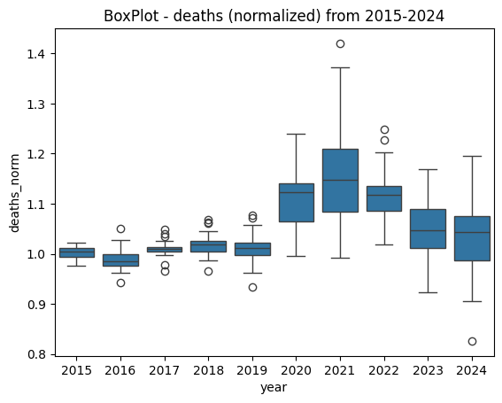

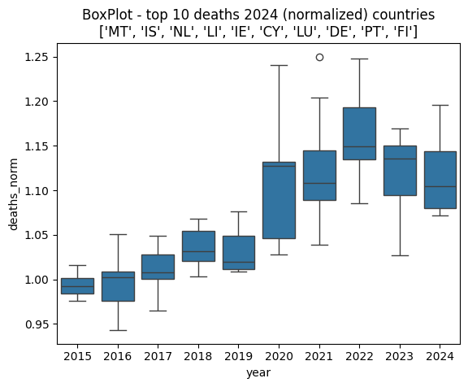

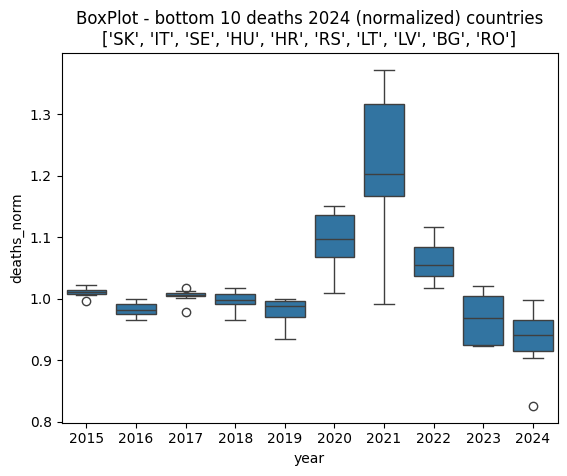

```python
# Box Plots

# Create the box plot
sns.boxplot(
    x="year",
    y="deaths_norm",
    data=ddy
    )
# Add a title
plt.title("BoxPlot - deaths (normalized) from 2015-2024")
# Show the plot
plt.show()

# Create the box plot
sns.boxplot(
    x="year",
    y="deaths_norm",
    data=ddy[ddy.abbr.isin(ddr2024.head(10).abbr)]
    )
# Add a title
plt.title(f"BoxPlot - top 10 deaths 2024 (normalized) countries\n{ddr2024.head(10).abbr.to_list()}")
# Show the plot
plt.show()

# Create the box plot
sns.boxplot(
    x="year",
    y="deaths_norm",
    data=ddy[ddy.abbr.isin(ddr2024.tail(10).abbr)]
    )
# Add a title
plt.title(f"BoxPlot - bottom 10 deaths 2024 (normalized) countries\n{ddr2024.tail(10).abbr.to_list()}")
# Show the plot
plt.show()
```

```python
title = 'Map of Europe 2024'
display(MD(f'### {title}'))
report = r"docs\ddr2024_map.html"

temp = ddr2024.copy()
temp['iso_alpha'] = temp.abbr.apply(abbr_to_isoalpha3)
temp['size'] = pow(temp[2024],30)

fig = px.scatter_geo(
    temp,
    locations="iso_alpha",
    color="name",
    hover_name=2024,
    size='size',
    projection="natural earth",
    # projection="orthographic",
    # projection="equirectangular",
    scope="europe",
    height=750,
    title=title,
    opacity=0.5,
    size_max=50,
)
fig.update_layout(template="plotly_dark")
pio.write_html(fig, file=report, auto_open=True)

display(FileLink(report))
display(MD('[weblink](https://jgarza9788.github.io/Excess_Mortality_And_Vaccines_In_Europe/ddr2024_map.html)'))

fig.show()
```

Map of Europe 2024

docs\ddr2024_map.html

[weblink](https://jgarza9788.github.io/Excess_Mortality_And_Vaccines_In_Europe/ddr2024_map.html)

## Observations

The recovery from the COVID-19 pandemic varies significantly across countries. What factors might explain these differences?

## Hypothesis

Based on reports such as:

- [U.S. COVID Deaths Are Rising Again. Experts Call It A 'Pandemic Of The Unvaccinated'](https://www.npr.org/2021/07/16/1017002907/u-s-covid-deaths-are-rising-again-experts-call-it-a-pandemic-of-the-unvaccinated)
- [CDC Warns of 'Pandemic of the Unvaccinated'](https://www.cnn.com/videos/health/2021/07/21/delta-variant-coronavirus-vaccines-cohen-newday-vpx.cnn)
- [Covid: French uproar as Macron vows to 'piss off' unvaccinated](https://www.bbc.com/news/world-europe-59873833?utm_source=chatgpt.com)
- [Don Lemon Unloads on Unvaxxed: We Have to ‘Do Things For The Greater Good Of Society, Not For Idiots’](https://www.mediaite.com/tv/don-lemon-unloads-on-unvaxxed-we-have-to-do-things-for-the-greater-good-of-society-not-for-idiots/?utm_source=chatgpt.com)
- [People Who Skip Vaccinations 'Incredibly Selfish' Experts Say](https://www.yahoo.com/lifestyle/people-who-skip-vaccinations-incredibly-selfish-108914416747.html?utm_source=chatgpt.com)
- plague rats
- selfish
- idiots
- anti-science
- ignorant
- irresponsible.

**Could countries with lower vaccination rates also be struggling more to recover from the pandemic?**  
Let’s test this hypothesis.

.  
.  
.  
.  
.  
.  
.  
.  
.  
.  
.  
.  
.  
.  
.  
.  
.  
.  
.  
.  
.  
.  
.  
.  
.  
.  
.  
.  
.  
.  
.  
.

### Vaccine Data

#### Source

- [Vaccine Tracker](https://vaccinetracker.ecdc.europa.eu/public/extensions/Covid-19/vaccine-tracker.html#uptake-tab)
- [Data Download](https://www.ecdc.europa.eu/en/publications-data/data-covid-19-vaccination-eu-eea): Download the dataset in CSV format.

#### Description

This dataset provides detailed information on COVID-19 vaccinations within the EU/EEA, as collected through **The European Surveillance System (TESSy)**. It includes indicators such as:

- Number of vaccine doses distributed by manufacturers.
- Number of first, second, additional, and unspecified doses administered.
- Data categorized by target groups at the national level.

**Key Notes**:

- Member States report data every four weeks.
- Retrospective corrections are applied, and updated datasets are released regularly.
- Data usage is subject to ECDC’s copyright policy.

#### Variables

- `vd`: Base vaccine dataset.
- `vdr2023`: Vaccination data ranked by the cumulative sum for 2023.
- `vdravg`: Vaccination data ranked by the average cumulative sum for 2020, 2021, 2022, and 2023.

### Import and Cleaning

```python
# we have to import it like this, because i ran out of memory the other way.WindowsError
# sorry ?

file = os.path.join(DataDIR,"data.csv")
vd = None
with open(file,'r',encoding='utf-8') as f:
    cols = f.readline().strip().split(',')
    vd = pd.read_csv(f, names=cols, skiprows=1, encoding='utf-8')

if len(vd) == 813366:
    print('✅ - number of rows match')
else:
    print('number of rows do not match, did you import a new spreadsheet?')

# display(vd.head(5))
# display(vd.tail(5))
```

```
✅ - number of rows match
```

```python
# i only care about the total vaccines (not broken into Age group)
vd = vd[vd.TargetGroup == 'ALL']
vd =vd.drop(columns=['TargetGroup'])

# calculate the sum of all the Doses
vd = pd.pivot_table(
    data = vd,
    values = ['FirstDose','SecondDose','DoseAdditional1','DoseAdditional2','DoseAdditional3','DoseAdditional4','DoseAdditional5','UnknownDose'],
    index = ['ReportingCountry','YearWeekISO','Population'],
    aggfunc="sum"
    )
vd = vd.reset_index()

# convert to a number
vd['year'] = pd.to_numeric(vd['YearWeekISO'].str[0:4])
vd['week'] = pd.to_numeric(vd['YearWeekISO'].str[6:8])
vd['year.week'] = vd['year'] + (vd['week']/100.0)
vd['year.p'] = vd['year'] + (vd['week']/53.001)

vd = vd.rename(columns={'ReportingCountry':'abbr'})
vd['name'] = vd.abbr.apply(abbr_to_name)

# gets get the total doses given
doseCol = ['FirstDose','SecondDose','DoseAdditional1','DoseAdditional2','DoseAdditional3','DoseAdditional4','DoseAdditional5','UnknownDose']
vd['total_dose'] = vd[doseCol].sum(axis=1)

# # lets get the doses as a percent of the population
vd['total_dose_ratio'] = vd['total_dose']/vd['Population']
vd['1_does_ratio'] = vd['FirstDose']/vd['Population']
vd['2_does_ratio'] = vd['SecondDose']/vd['Population']
vd = vd.drop(columns=doseCol)

# Calculate cumulative sum for each column, grouped by 'abbr'
vd['td_cumsum'] = vd.groupby('abbr')['total_dose_ratio'].cumsum()
vd['1d_cumsum'] = vd.groupby('abbr')['1_does_ratio'].cumsum()
vd['2d_cumsum'] = vd.groupby('abbr')['2_does_ratio'].cumsum()

# lets drop the columns we don't need anymore
vd = vd.drop(columns=['YearWeekISO'])

# filling unknown values with 0.0
vd = vd.fillna(0.0)

display(vd.head(10))
```

|  | abbr | Population | year | week | year.week | year.p | name | total_dose | total_dose_ratio | 1_does_ratio | 2_does_ratio | td_cumsum | 1d_cumsum | 2d_cumsum |
| --- | --- | --- | --- | --- | --- | --- | --- | --- | --- | --- | --- | --- | --- | --- |
| 0 | AT | 8901064 | 2020 | 53 | 2020.53 | 2020.999981 | Austria | 5354 | 0.000602 | 0.000601 | 0.000000e+00 | 0.000602 | 0.000601 | 0.000000e+00 |
| 1 | AT | 8932664 | 2021 | 1 | 2021.01 | 2021.018868 | Austria | 26404 | 0.002956 | 0.002955 | 3.358461e-07 | 0.003557 | 0.003555 | 3.358461e-07 |
| 2 | AT | 8932664 | 2021 | 2 | 2021.02 | 2021.037735 | Austria | 85796 | 0.009605 | 0.009556 | 4.578701e-05 | 0.013162 | 0.013111 | 4.612286e-05 |
| 3 | AT | 8932664 | 2021 | 3 | 2021.03 | 2021.056603 | Austria | 98483 | 0.011025 | 0.010488 | 5.217928e-04 | 0.024187 | 0.023599 | 5.679157e-04 |
| 4 | AT | 8932664 | 2021 | 4 | 2021.04 | 2021.075470 | Austria | 49484 | 0.005540 | 0.003550 | 1.973655e-03 | 0.029727 | 0.027148 | 2.541571e-03 |
| 5 | AT | 8932664 | 2021 | 5 | 2021.05 | 2021.094338 | Austria | 98629 | 0.011041 | 0.002093 | 8.936864e-03 | 0.040768 | 0.029241 | 1.147843e-02 |
| 6 | AT | 8932664 | 2021 | 6 | 2021.06 | 2021.113205 | Austria | 117962 | 0.013206 | 0.003235 | 9.937685e-03 | 0.053974 | 0.032477 | 2.141612e-02 |
| 7 | AT | 8932664 | 2021 | 7 | 2021.07 | 2021.132073 | Austria | 103892 | 0.011631 | 0.007134 | 4.460931e-03 | 0.065605 | 0.039610 | 2.587705e-02 |
| 8 | AT | 8932664 | 2021 | 8 | 2021.08 | 2021.150941 | Austria | 128773 | 0.014416 | 0.011997 | 2.401859e-03 | 0.080020 | 0.051607 | 2.827891e-02 |
| 9 | AT | 8932664 | 2021 | 9 | 2021.09 | 2021.169808 | Austria | 170409 | 0.019077 | 0.017352 | 1.702404e-03 | 0.099098 | 0.068960 | 2.998131e-02 |

### Viewing the Vaccine Data

This section focuses on exploring the vaccine data to ensure it is correctly loaded and processed. We will inspect the data's structure, check for anomalies, and visualize key trends.

```python
title = 'Line Chart - Percent Vaccinations in Europe 2020-2023 (per Year)'
display(MD(f'### {title}'))
report = r"docs\vdy_line.html"

temp = pd.pivot_table(
    data = vd,
    values = 'total_dose_ratio',
    index = ['abbr','name','year'],
    aggfunc="sum"
)
temp = temp.reset_index()

fig = px.line(
    temp,
    x='year',
    y='total_dose_ratio',
    color='name',
    height=750 ,
    title=title
    )
fig.update_layout(template="plotly_dark")
pio.write_html(fig, file=report, auto_open=True)

display(FileLink(report))
display(MD('[weblink](https://jgarza9788.github.io/Excess_Mortality_And_Vaccines_In_Europe/vdy_line.html)'))

fig.show()
```

Line Chart - Percent Vaccinations in Europe 2020-2023 (per Year)

docs\vdy_line.html

[weblink](https://jgarza9788.github.io/Excess_Mortality_And_Vaccines_In_Europe/vdy_line.html)

```python
title = 'Line Chart - percent vaccinations in Europe 2020-2023 (per week)'
display(MD(f'### {title}'))
report = r"docs\vd_line.html"

temp = pd.pivot_table(
    data = vd,
    values = 'total_dose_ratio',
    index = ['abbr','name','year.p'],
    aggfunc="sum"
)
temp = temp.reset_index()

fig = px.line(
    temp,
    x='year.p',
    y='total_dose_ratio',
    color='name',
    height=750 ,
    title=title
    )
fig.update_layout(template="plotly_dark")
pio.write_html(fig, file=report, auto_open=True)

display(FileLink(report))
display(MD('[weblink](https://jgarza9788.github.io/Excess_Mortality_And_Vaccines_In_Europe/vd_line.html)'))

fig.show()
```

Line Chart - percent vaccinations in Europe 2020-2023 (per week)

docs\vd_line.html

[weblink](https://jgarza9788.github.io/Excess_Mortality_And_Vaccines_In_Europe/vd_line.html)

```python
title = 'Line Chart - Cumulative Sum of Vaccines in Europe 2020-2023'
display(MD(f'### {title}'))
report = r"docs\vdcumsum_line.html"


temp = pd.pivot_table(
    data = vd,
    values = 'td_cumsum',
    index = ['abbr','name','year.p'],
    aggfunc="sum"
)
temp = temp.reset_index()

fig = px.line(
    temp,
    x='year.p',
    y='td_cumsum',
    color='name',
    height=750 ,
    title=title
    )
fig.update_layout(template="plotly_dark")
pio.write_html(fig, file=report, auto_open=True)

display(FileLink(report))
display(MD('[weblink](https://jgarza9788.github.io/Excess_Mortality_And_Vaccines_In_Europe/vdcumsum_line.html)'))

fig.show()
```

Line Chart - Cumulative Sum of Vaccines in Europe 2020-2023

docs\vdcumsum_line.html

[weblink](https://jgarza9788.github.io/Excess_Mortality_And_Vaccines_In_Europe/vdcumsum_line.html)

```python
display(vd.head(10))
```

|  | abbr | Population | year | week | year.week | year.p | name | total_dose | total_dose_ratio | 1_does_ratio | 2_does_ratio | td_cumsum | 1d_cumsum | 2d_cumsum |
| --- | --- | --- | --- | --- | --- | --- | --- | --- | --- | --- | --- | --- | --- | --- |
| 0 | AT | 8901064 | 2020 | 53 | 2020.53 | 2020.999981 | Austria | 5354 | 0.000602 | 0.000601 | 0.000000e+00 | 0.000602 | 0.000601 | 0.000000e+00 |
| 1 | AT | 8932664 | 2021 | 1 | 2021.01 | 2021.018868 | Austria | 26404 | 0.002956 | 0.002955 | 3.358461e-07 | 0.003557 | 0.003555 | 3.358461e-07 |
| 2 | AT | 8932664 | 2021 | 2 | 2021.02 | 2021.037735 | Austria | 85796 | 0.009605 | 0.009556 | 4.578701e-05 | 0.013162 | 0.013111 | 4.612286e-05 |
| 3 | AT | 8932664 | 2021 | 3 | 2021.03 | 2021.056603 | Austria | 98483 | 0.011025 | 0.010488 | 5.217928e-04 | 0.024187 | 0.023599 | 5.679157e-04 |
| 4 | AT | 8932664 | 2021 | 4 | 2021.04 | 2021.075470 | Austria | 49484 | 0.005540 | 0.003550 | 1.973655e-03 | 0.029727 | 0.027148 | 2.541571e-03 |
| 5 | AT | 8932664 | 2021 | 5 | 2021.05 | 2021.094338 | Austria | 98629 | 0.011041 | 0.002093 | 8.936864e-03 | 0.040768 | 0.029241 | 1.147843e-02 |
| 6 | AT | 8932664 | 2021 | 6 | 2021.06 | 2021.113205 | Austria | 117962 | 0.013206 | 0.003235 | 9.937685e-03 | 0.053974 | 0.032477 | 2.141612e-02 |
| 7 | AT | 8932664 | 2021 | 7 | 2021.07 | 2021.132073 | Austria | 103892 | 0.011631 | 0.007134 | 4.460931e-03 | 0.065605 | 0.039610 | 2.587705e-02 |
| 8 | AT | 8932664 | 2021 | 8 | 2021.08 | 2021.150941 | Austria | 128773 | 0.014416 | 0.011997 | 2.401859e-03 | 0.080020 | 0.051607 | 2.827891e-02 |
| 9 | AT | 8932664 | 2021 | 9 | 2021.09 | 2021.169808 | Austria | 170409 | 0.019077 | 0.017352 | 1.702404e-03 | 0.099098 | 0.068960 | 2.998131e-02 |

```python
display(MD('### HeatMap (vaccination (cumulative sum) by year)'))
temp = pd.pivot_table(
    data = vd.copy(),
    values = 'td_cumsum',
    index = ['abbr','name'],
    columns=['year'],
    aggfunc='sum',
)
temp.columns.name = 'index'

# fill unknwon values with 0.0
temp = temp.fillna(0.0)

temp = temp.sort_values(by=2023,ascending=False)
temp = temp.reset_index()

vdr2023 = temp.copy()

display(temp.style.background_gradient(cmap=heatmapCM,axis=1))
```

HeatMap (vaccination (cumulative sum) by year)

| index | abbr | name | 2020 | 2021 | 2022 | 2023 |
| --- | --- | --- | --- | --- | --- | --- |
| 0 | FI | Finland | 0.003119 | 123.689548 | 324.096693 | 272.896203 |
| 1 | PT | Portugal | 0.008074 | 94.765752 | 242.524514 | 206.590389 |
| 2 | IT | Italy | 0.004416 | 87.617659 | 233.812064 | 185.254382 |
| 3 | SE | Sweden | 0.002223 | 80.134686 | 207.824977 | 169.837101 |
| 4 | FR | France | 0.000154 | 85.965138 | 222.847236 | 123.812258 |
| 5 | LT | Lithuania | 0.008713 | 73.887973 | 159.737318 | 121.514759 |
| 6 | PL | Poland | 0.002875 | 65.427576 | 140.960642 | 111.134565 |
| 7 | DK | Denmark | 0.007972 | 44.968313 | 111.526055 | 94.077417 |
| 8 | IE | Ireland | 0.000886 | 45.028201 | 109.794808 | 88.523542 |
| 9 | NL | Netherlands | 0.000001 | 38.864806 | 101.500325 | 85.977226 |
| 10 | ES | Spain | 0.002037 | 44.471692 | 103.575461 | 85.551832 |
| 11 | BE | Belgium | 0.000085 | 45.390091 | 111.537012 | 84.741858 |
| 12 | MT | Malta | 0.003113 | 55.425318 | 117.396957 | 81.903319 |
| 13 | EL | Greece | 0.000409 | 37.723542 | 98.374150 | 77.927167 |
| 14 | DE | Germany | 0.003932 | 43.312437 | 108.907243 | 77.432527 |
| 15 | NO | Norway | 0.000460 | 42.590518 | 106.774369 | 77.299424 |
| 16 | LU | Luxembourg | 0.001350 | 37.930549 | 96.015093 | 75.633132 |
| 17 | CY | Cyprus | 0.003805 | 41.832246 | 99.470441 | 72.091795 |
| 18 | LI | Liechtenstein | 0.000000 | 38.331481 | 90.809788 | 71.186504 |
| 19 | CZ | Czechia | 0.001455 | 36.163238 | 83.640865 | 65.776328 |
| 20 | EE | Estonia | 0.002088 | 35.576595 | 78.305111 | 61.723992 |
| 21 | HU | Hungary | 0.001327 | 43.386551 | 82.610516 | 61.222052 |
| 22 | AT | Austria | 0.000602 | 41.786591 | 103.093153 | 55.847500 |
| 23 | SI | Slovenia | 0.006222 | 31.459218 | 69.615364 | 52.379093 |
| 24 | HR | Croatia | 0.003747 | 29.649887 | 67.318861 | 52.133253 |
| 25 | LV | Latvia | 0.001187 | 28.184231 | 74.872405 | 47.705397 |
| 26 | SK | Slovakia | 0.000888 | 29.569229 | 65.278902 | 47.148960 |
| 27 | IS | Iceland | 0.013575 | 47.087520 | 103.639489 | 45.329537 |
| 28 | RO | Romania | 0.000000 | 20.721981 | 41.032540 | 31.630294 |
| 29 | BG | Bulgaria | 0.000682 | 12.669190 | 32.903872 | 25.084732 |

```python
vdravg = vdr2023.copy()
vdravg['avg2020_2023'] = ( vdravg[2020] + vdravg[2021] + vdravg[2022] + vdravg[2023] )/4.0
vdravg = vdravg.sort_values(by='avg2020_2023',ascending=False)
vdravg = vdravg.reset_index(drop=True)

vdravg = vdravg.drop(columns=[2020,2021,2022,2023])

display(vdravg.style.background_gradient(cmap=heatmapCM,axis=1))
```

| index | abbr | name | avg2020_2023 |
| --- | --- | --- | --- |
| 0 | FI | Finland | 180.171391 |
| 1 | PT | Portugal | 135.972182 |
| 2 | IT | Italy | 126.672130 |
| 3 | SE | Sweden | 114.449747 |
| 4 | FR | France | 108.156197 |
| 5 | LT | Lithuania | 88.787191 |
| 6 | PL | Poland | 79.381415 |
| 7 | MT | Malta | 63.682177 |
| 8 | DK | Denmark | 62.644939 |
| 9 | IE | Ireland | 60.836859 |
| 10 | BE | Belgium | 60.417262 |
| 11 | ES | Spain | 58.400255 |
| 12 | DE | Germany | 57.414035 |
| 13 | NO | Norway | 56.666193 |
| 14 | NL | Netherlands | 56.585590 |
| 15 | EL | Greece | 53.506317 |
| 16 | CY | Cyprus | 53.349572 |
| 17 | LU | Luxembourg | 52.395031 |
| 18 | AT | Austria | 50.181961 |
| 19 | LI | Liechtenstein | 50.081943 |
| 20 | IS | Iceland | 49.017530 |
| 21 | HU | Hungary | 46.805112 |
| 22 | CZ | Czechia | 46.395471 |
| 23 | EE | Estonia | 43.901946 |
| 24 | SI | Slovenia | 38.364974 |
| 25 | LV | Latvia | 37.690805 |
| 26 | HR | Croatia | 37.276437 |
| 27 | SK | Slovakia | 35.499495 |
| 28 | RO | Romania | 23.346204 |
| 29 | BG | Bulgaria | 17.664619 |

```python
display(MD('### HeatMap - vaccination (cumulative sum) by week'))
temp = pd.pivot_table(
    data = vd.copy(),
    values = 'td_cumsum',
    index = ['abbr','name'],
    columns=['year.p'],
    aggfunc='sum',
)
temp.columns.name = 'index'

# fill unknwon values with 0.0
temp = temp.fillna(0.0)

# temp = temp.sort_values(by=2023,ascending=False)
temp = temp.reset_index()
temp = temp.set_index('name').reindex(vdr2023['name']).reset_index()
# temp = temp.reset_index()

display(temp.style.background_gradient(cmap=heatmapCM))
```

HeatMap - vaccination (cumulative sum) by week

| index | name | abbr | 2020.943378 | 2020.962246 | 2020.981114 | 2020.999981 | 2021.018868 | 2021.037735 | 2021.056603 | 2021.075470 | 2021.094338 | 2021.113205 | 2021.132073 | 2021.150941 | 2021.169808 | 2021.188676 | 2021.207543 | 2021.226411 | 2021.245278 | 2021.264146 | 2021.283014 | 2021.301881 | 2021.320749 | 2021.339616 | 2021.358484 | 2021.377351 | 2021.396219 | 2021.415087 | 2021.433954 | … |
| --- | --- | --- | --- | --- | --- | --- | --- | --- | --- | --- | --- | --- | --- | --- | --- | --- | --- | --- | --- | --- | --- | --- | --- | --- | --- | --- | --- | --- | --- | --- |
| 0 | Finland | FI | 0.000000 | 0.000000 | 0.000015 | 0.003104 | 0.011744 | 0.033866 | 0.065379 | 0.095975 | 0.126334 | 0.157116 | 0.203140 | 0.259158 | 0.321089 | 0.388604 | 0.457742 | 0.517702 | 0.590158 | 0.684456 | 0.813271 | 0.933617 | 1.049552 | 1.181673 | 1.309672 | 1.459119 | 1.606969 | 1.768479 | 1.953522 | … |
| 1 | Portugal | PT | 0.000000 | 0.000000 | 0.001010 | 0.007064 | 0.016606 | 0.026703 | 0.057092 | 0.074330 | 0.086598 | 0.114230 | 0.144606 | 0.183722 | 0.218137 | 0.247945 | 0.286484 | 0.342194 | 0.386872 | 0.448842 | 0.543968 | 0.613970 | 0.700818 | 0.818259 | 0.936063 | 1.040324 | 1.151709 | 1.264678 | 1.385727 | … |
| 2 | Italy | IT | 0.000000 | 0.000000 | 0.000241 | 0.004175 | 0.022542 | 0.040851 | 0.049075 | 0.068021 | 0.088523 | 0.103283 | 0.120381 | 0.147580 | 0.186828 | 0.230471 | 0.268276 | 0.322405 | 0.379747 | 0.446276 | 0.520844 | 0.604366 | 0.705115 | 0.816517 | 0.931652 | 1.048284 | 1.167970 | 1.292023 | 1.422258 | … |
| 3 | Sweden | SE | 0.000000 | 0.000000 | 0.000271 | 0.001953 | 0.006539 | 0.018729 | 0.037189 | 0.051314 | 0.066496 | 0.084409 | 0.111637 | 0.139339 | 0.173511 | 0.213378 | 0.244412 | 0.280065 | 0.328979 | 0.393394 | 0.482912 | 0.566483 | 0.642746 | 0.730026 | 0.811154 | 0.897883 | 0.990485 | 1.102500 | 1.233135 | … |
| 4 | France | FR | 0.000000 | 0.000000 | 0.000018 | 0.000136 | 0.003277 | 0.013658 | 0.033851 | 0.051294 | 0.068995 | 0.092574 | 0.117109 | 0.142342 | 0.181395 | 0.228378 | 0.265851 | 0.320855 | 0.380055 | 0.443712 | 0.519996 | 0.595825 | 0.678595 | 0.775228 | 0.881068 | 0.989907 | 1.091502 | 1.211257 | 1.330599 | … |
| 5 | Lithuania | LT | 0.000000 | 0.000000 | 0.001734 | 0.006979 | 0.016863 | 0.037326 | 0.048792 | 0.067178 | 0.089086 | 0.109364 | 0.135238 | 0.170274 | 0.212540 | 0.253587 | 0.287439 | 0.341519 | 0.406473 | 0.484348 | 0.556312 | 0.630231 | 0.716975 | 0.836473 | 0.940204 | 1.039380 | 1.136569 | 1.268173 | 1.362093 | … |
| 6 | Poland | PL | 0.000000 | 0.000000 | 0.000117 | 0.002758 | 0.011278 | 0.025716 | 0.038599 | 0.063627 | 0.089863 | 0.115091 | 0.146682 | 0.179417 | 0.213136 | 0.241813 | 0.267924 | 0.313988 | 0.355723 | 0.410282 | 0.473729 | 0.549144 | 0.637357 | 0.733977 | 0.846519 | 0.952631 | 1.054317 | 1.169427 | 1.289397 | … |
| 7 | Denmark | DK | 0.000000 | 0.000002 | 0.000870 | 0.007100 | 0.015760 | 0.023424 | 0.028543 | 0.037418 | 0.046110 | 0.056163 | 0.069738 | 0.088341 | 0.108581 | 0.123505 | 0.139829 | 0.156241 | 0.176021 | 0.199987 | 0.239915 | 0.276654 | 0.315860 | 0.371865 | 0.427465 | 0.486799 | 0.542474 | 0.604912 | 0.680811 | … |
| 8 | Ireland | IE | 0.000000 | 0.000000 | 0.000000 | 0.000886 | 0.010658 | 0.020524 | 0.030634 | 0.041540 | 0.052348 | 0.059107 | 0.076370 | 0.094276 | 0.111901 | 0.130136 | 0.143922 | 0.170657 | 0.198938 | 0.225412 | 0.256480 | 0.296190 | 0.339471 | 0.390494 | 0.456183 | 0.522773 | 0.584830 | 0.640393 | 0.699713 | … |
| 9 | Netherlands | NL | 0.000000 | 0.000000 | 0.000000 | 0.000001 | 0.001984 | 0.004387 | 0.009305 | 0.017364 | 0.027415 | 0.038091 | 0.050023 | 0.066466 | 0.079856 | 0.092930 | 0.103452 | 0.117838 | 0.140900 | 0.167245 | 0.206832 | 0.244086 | 0.280954 | 0.322706 | 0.373593 | 0.433079 | 0.489287 | 0.551229 | 0.637726 | … |
| 10 | Spain | ES | 0.000000 | 0.000000 | 0.000000 | 0.002037 | 0.008865 | 0.019603 | 0.026809 | 0.034741 | 0.045712 | 0.055825 | 0.066879 | 0.083070 | 0.102207 | 0.121829 | 0.136472 | 0.162374 | 0.189651 | 0.231942 | 0.274110 | 0.313905 | 0.365125 | 0.421744 | 0.474305 | 0.523734 | 0.572090 | 0.635338 | 0.706892 | … |
| 11 | Belgium | BE | 0.000000 | 0.000000 | 0.000000 | 0.000085 | 0.002456 | 0.011059 | 0.021751 | 0.029767 | 0.041866 | 0.054601 | 0.064769 | 0.075761 | 0.090848 | 0.107755 | 0.133203 | 0.160880 | 0.191059 | 0.229774 | 0.272610 | 0.309644 | 0.348965 | 0.412781 | 0.465451 | 0.531436 | 0.587185 | 0.665713 | 0.758970 | … |
| 12 | Malta | MT | 0.000000 | 0.000000 | 0.000111 | 0.003003 | 0.008817 | 0.021381 | 0.036634 | 0.051429 | 0.076451 | 0.097969 | 0.128825 | 0.177066 | 0.227911 | 0.283239 | 0.335630 | 0.390668 | 0.447283 | 0.504421 | 0.574097 | 0.648945 | 0.713640 | 0.789672 | 0.884252 | 0.984597 | 1.071334 | 1.130772 | 1.195140 | … |
| 13 | Greece | EL | 0.000000 | 0.000000 | 0.000029 | 0.000380 | 0.004240 | 0.007720 | 0.015342 | 0.025844 | 0.037714 | 0.049852 | 0.066199 | 0.084005 | 0.103258 | 0.121488 | 0.135866 | 0.151942 | 0.173281 | 0.205194 | 0.235708 | 0.266900 | 0.294642 | 0.345076 | 0.405941 | 0.464297 | 0.519573 | 0.581308 | 0.645370 | … |
| 14 | Germany | DE | 0.000000 | 0.000000 | 0.000293 | 0.003639 | 0.008156 | 0.014670 | 0.022825 | 0.030578 | 0.040747 | 0.051250 | 0.062251 | 0.076204 | 0.094727 | 0.116451 | 0.134015 | 0.159189 | 0.182620 | 0.222675 | 0.267258 | 0.309981 | 0.366926 | 0.428130 | 0.488575 | 0.550343 | 0.612136 | 0.676907 | 0.755643 | … |
| 15 | Norway | NO | 0.000000 | 0.000000 | 0.000013 | 0.000447 | 0.004388 | 0.009818 | 0.015528 | 0.024699 | 0.042896 | 0.058892 | 0.075618 | 0.095516 | 0.116610 | 0.135781 | 0.147906 | 0.170616 | 0.190206 | 0.223636 | 0.261116 | 0.291953 | 0.334048 | 0.373616 | 0.411145 | 0.453630 | 0.501445 | 0.566461 | 0.624523 | … |
| 16 | Luxembourg | LU | 0.000000 | 0.000000 | 0.000002 | 0.001348 | 0.002038 | 0.004389 | 0.008480 | 0.013725 | 0.019854 | 0.025311 | 0.034791 | 0.042981 | 0.055202 | 0.073768 | 0.097249 | 0.115469 | 0.145373 | 0.183655 | 0.236360 | 0.258618 | 0.290808 | 0.353755 | 0.421568 | 0.475923 | 0.515773 | 0.583851 | 0.661438 | … |
| 17 | Cyprus | CY | 0.000000 | 0.000000 | 0.000416 | 0.003390 | 0.006856 | 0.012154 | 0.020254 | 0.028380 | 0.037050 | 0.049605 | 0.065375 | 0.087638 | 0.110864 | 0.138324 | 0.147106 | 0.165128 | 0.180609 | 0.207196 | 0.235359 | 0.270212 | 0.328666 | 0.399966 | 0.487634 | 0.579572 | 0.659004 | 0.717636 | 0.777079 | … |
| 18 | Liechtenstein | LI | 0.000000 | 0.000000 | 0.000000 | 0.000000 | 0.000102 | 0.001127 | 0.009679 | 0.020817 | 0.023557 | 0.032160 | 0.049904 | 0.068365 | 0.083370 | 0.100755 | 0.117014 | 0.146435 | 0.172859 | 0.196108 | 0.233927 | 0.301344 | 0.341416 | 0.376290 | 0.426911 | 0.497606 | 0.554500 | 0.625963 | 0.699219 | … |
| 19 | Czechia | CZ | 0.000000 | 0.000000 | 0.000119 | 0.001337 | 0.004749 | 0.011683 | 0.019938 | 0.026779 | 0.034628 | 0.044385 | 0.053585 | 0.063828 | 0.081637 | 0.106194 | 0.130894 | 0.152734 | 0.175637 | 0.203355 | 0.239520 | 0.273376 | 0.309842 | 0.353317 | 0.399798 | 0.449782 | 0.503572 | 0.565320 | 0.630256 | … |
| 20 | Estonia | EE | 0.000000 | 0.000000 | 0.000147 | 0.001941 | 0.008403 | 0.014097 | 0.020163 | 0.029753 | 0.041174 | 0.052633 | 0.068286 | 0.086847 | 0.112751 | 0.147235 | 0.173181 | 0.196889 | 0.228272 | 0.258079 | 0.288538 | 0.317893 | 0.359206 | 0.411544 | 0.448171 | 0.496303 | 0.544860 | 0.591098 | 0.643539 | … |
| 21 | Hungary | HU | 0.000000 | 0.000000 | 0.000112 | 0.001215 | 0.007375 | 0.012693 | 0.016044 | 0.031135 | 0.040770 | 0.049307 | 0.067927 | 0.098104 | 0.136122 | 0.180069 | 0.213843 | 0.268764 | 0.337177 | 0.423097 | 0.477681 | 0.539645 | 0.629271 | 0.694546 | 0.741073 | 0.803135 | 0.873871 | 0.921813 | 0.949764 | … |
| 22 | Austria | AT | 0.000000 | 0.000000 | 0.000000 | 0.000602 | 0.003557 | 0.013162 | 0.024187 | 0.029727 | 0.040768 | 0.053974 | 0.065605 | 0.080020 | 0.099098 | 0.128155 | 0.155012 | 0.183041 | 0.208360 | 0.248194 | 0.290418 | 0.330112 | 0.370473 | 0.421435 | 0.469305 | 0.530230 | 0.585269 | 0.650110 | 0.720406 | … |
| 23 | Slovenia | SI | 0.000000 | 0.000000 | 0.001774 | 0.004447 | 0.012755 | 0.020692 | 0.026367 | 0.034699 | 0.042998 | 0.052122 | 0.062740 | 0.075114 | 0.089885 | 0.112929 | 0.126259 | 0.150868 | 0.178182 | 0.203599 | 0.230083 | 0.261008 | 0.288601 | 0.333684 | 0.379313 | 0.432001 | 0.477662 | 0.539593 | 0.593199 | … |
| 24 | Croatia | HR | 0.000000 | 0.000000 | 0.000530 | 0.003216 | 0.007975 | 0.012682 | 0.018762 | 0.022992 | 0.027496 | 0.034897 | 0.045320 | 0.061060 | 0.075505 | 0.091598 | 0.108513 | 0.124392 | 0.141528 | 0.159061 | 0.187454 | 0.213674 | 0.244592 | 0.303794 | 0.364825 | 0.418922 | 0.466145 | 0.500485 | 0.552654 | … |
| 25 | Latvia | LV | 0.000000 | 0.000000 | 0.000000 | 0.001187 | 0.003684 | 0.008436 | 0.010086 | 0.012589 | 0.017082 | 0.019813 | 0.024472 | 0.033364 | 0.043825 | 0.051850 | 0.054805 | 0.067631 | 0.079612 | 0.096154 | 0.114482 | 0.140661 | 0.172929 | 0.217322 | 0.276256 | 0.331664 | 0.392353 | 0.451521 | 0.498773 | … |
| 26 | Slovakia | SK | 0.000000 | 0.000000 | 0.000056 | 0.000832 | 0.005562 | 0.011697 | 0.018683 | 0.027346 | 0.039968 | 0.055063 | 0.068369 | 0.082463 | 0.100421 | 0.119884 | 0.144171 | 0.168290 | 0.187681 | 0.212573 | 0.241051 | 0.268909 | 0.299829 | 0.336412 | 0.379542 | 0.425080 | 0.470672 | 0.514758 | 0.558812 | … |
| 27 | Iceland | IS | 0.000000 | 0.000000 | 0.000000 | 0.013575 | 0.000000 | 0.016994 | 0.041669 | 0.042434 | 0.048299 | 0.054159 | 0.075661 | 0.091909 | 0.114455 | 0.128086 | 0.144242 | 0.180124 | 0.203159 | 0.242807 | 0.272919 | 0.310015 | 0.397667 | 0.510961 | 0.555251 | 0.629035 | 0.678199 | 0.743376 | 0.858075 | … |
| 28 | Romania | RO | 0.000000 | 0.000000 | 0.000000 | 0.000000 | 0.000000 | 0.000000 | 0.000000 | 0.036090 | 0.044647 | 0.058179 | 0.071987 | 0.079902 | 0.095419 | 0.112782 | 0.131582 | 0.152009 | 0.172495 | 0.192956 | 0.220767 | 0.252139 | 0.278347 | 0.313007 | 0.351753 | 0.381944 | 0.407228 | 0.428545 | 0.443243 | … |
| 29 | Bulgaria | BG | 0.000000 | 0.000000 | 0.000000 | 0.000682 | 0.001944 | 0.002665 | 0.003776 | 0.005942 | 0.008243 | 0.010896 | 0.017253 | 0.030712 | 0.041727 | 0.048992 | 0.053333 | 0.063112 | 0.072803 | 0.082793 | 0.092304 | 0.104568 | 0.119226 | 0.135628 | 0.161463 | 0.182284 | 0.195669 | 0.211723 | 0.227992 | … |

## let's compare a little bit

### Overlap Analysis

This section compares the top and bottom-ranked countries by deaths and vaccinations in 2023. The analysis checks for overlaps in the following scenarios:

1. Top-ranked deaths vs. top-ranked vaccinations.
2. Bottom-ranked deaths vs. bottom-ranked vaccinations.
3. Top-ranked deaths vs. bottom-ranked vaccinations.
4. Bottom-ranked deaths vs. top-ranked vaccinations.

The results provide insights into potential relationships between vaccination rates and death counts across countries.

```python
num = 10

display(MD(f'### Overlap -- head{num} deaths and head{num} vaccinated countries '))
overlap = list(set(ddr2023.head(num).abbr.to_list()) & set(vdr2023.head(num).abbr.to_list()))
display(MD(f'{len(overlap)=} out of {num}'))

display(MD(f'### Overlap -- tail{num} deaths and tail{num} vaccinated countries '))
overlap = list(set(ddr2023.tail(num).abbr.to_list()) & set(vdr2023.tail(num).abbr.to_list()))
display(MD(f'{len(overlap)=} out of {num}'))

display(MD(f'### Overlap -- head{num} deaths and tail{num} vaccinated countries '))
overlap = list(set(ddr2023.head(num).abbr.to_list()) & set(vdr2023.tail(num).abbr.to_list()))
display(MD(f'{len(overlap)=} out of {num}'))

display(MD(f'### Overlap -- tail{num} deaths and head{num} vaccinated countries '))
overlap = list(set(ddr2023.tail(num).abbr.to_list()) & set(vdr2023.head(num).abbr.to_list()))
display(MD(f'{len(overlap)=} out of {num}'))
```

Overlap -- head10 deaths and head10 vaccinated countries

len(overlap)=4 out of 10

Overlap -- tail10 deaths and tail10 vaccinated countries

len(overlap)=6 out of 10

Overlap -- head10 deaths and tail10 vaccinated countries

len(overlap)=2 out of 10

Overlap -- tail10 deaths and head10 vaccinated countries

len(overlap)=2 out of 10

lets also see the overlap with the 2024 deaths countries with the 2023 vaccines countries

```python
num = 10

display(MD(f'### Overlap -- head{num} deaths and head{num} vaccinated countries '))
overlap = list(set(ddr2024.head(num).abbr.to_list()) & set(vdr2023.head(num).abbr.to_list()))
display(MD(f'{len(overlap)=} out of {num}'))

display(MD(f'### Overlap -- tail{num} deaths and tail{num} vaccinated countries '))
overlap = list(set(ddr2024.tail(num).abbr.to_list()) & set(vdr2023.tail(num).abbr.to_list()))
display(MD(f'{len(overlap)=} out of {num}'))

display(MD(f'### Overlap -- head{num} deaths and tail{num} vaccinated countries '))
overlap = list(set(ddr2024.head(num).abbr.to_list()) & set(vdr2023.tail(num).abbr.to_list()))
display(MD(f'{len(overlap)=} out of {num}'))

display(MD(f'### Overlap -- tail{num} deaths and head{num} vaccinated countries '))
overlap = list(set(ddr2024.tail(num).abbr.to_list()) & set(vdr2023.head(num).abbr.to_list()))
display(MD(f'{len(overlap)=} out of {num}'))
```

Overlap -- head10 deaths and head10 vaccinated countries

len(overlap)=4 out of 10

Overlap -- tail10 deaths and tail10 vaccinated countries

len(overlap)=6 out of 10

Overlap -- head10 deaths and tail10 vaccinated countries

len(overlap)=1 out of 10

Overlap -- tail10 deaths and head10 vaccinated countries

len(overlap)=3 out of 10

### Correlation Analysis

This section analyzes the relationship between two ranked datasets:

1. Death data ranks (`ddr2024`).
2. Vaccination data ranks (`vdr2023`).

The ranks are compared to identify similarities in their ordering using two statistical methods: **Spearman's Rank Correlation** and **Kendall's Tau**.

#### Steps:

1. **Preprocessing**:
   - The death data (`ddr2024`) and vaccination data (`vdr2023`) are copied and reset to ensure a clean comparison.
   - Irrelevant columns (e.g., yearly data) are removed, keeping only the relevant ranking information.
   - Data from both datasets are filtered to include only matching country abbreviations (`abbr`).
2. **Rank Alignment**:
   - Vaccination ranks from `vdr2023` are assigned to the corresponding countries in the death data (`ddr2024`), ensuring both datasets are aligned for comparison.
3. **Output Interpretation**: A summary of the correlation output is provided:
   - **1**: Indicates strong similarity in the order of ranks.
   - **-1**: Indicates a strong inverse relationship in ranks.
   - **0**: Suggests no correlation in the order.
4. **Statistical Methods**:
   - **Spearman's Rank Correlation**: Measures the strength and direction of the monotonic relationship between two ranked variables.
     - **Range**: `-1` (perfect inverse) to `1` (perfect similarity).
     - Use Case: Detects whether higher ranks in one dataset correspond to higher ranks in the other (or inversely).
   - **Kendall's Tau**: Measures the strength of association between two ranked variables based on concordant and discordant pairs.
     - **Range**: `-1` (perfect inverse) to `1` (perfect similarity).
     - Use Case: Evaluates rank agreement between two datasets, factoring in the proportion of pairwise agreements.

#### Outputs:

- **Spearman's Rank Correlation**: Reflects how well the relationship between the rankings can be described as monotonic.
- **Kendall's Tau**: Provides a stricter measure of rank agreement, focusing on pairwise comparisons.

The results help assess whether vaccination rates and death rates have a correlated ordering across countries.

```python
d = ddr2024.copy().reset_index()
d = d.rename(columns={'index':'value'})
d = d.drop(columns=[2015,2016,2017,2018,2019,2020,2021,2022,2023,2024])
# d['rank'] = d['value'].rank()

v = vdr2023.copy().reset_index()
v = v.rename(columns={'index':'value'})
v = v.drop(columns=[2020,2021,2022,2023])
v['rank'] = v['value'].rank()


d = d[d.abbr.isin(v.abbr)]

for i, row in v.iterrows():
    d.loc[d['abbr']==row['abbr'], 'rank'] = row['rank']

# display(d)
# display(v)


display(MD(
'''### Output Interpretation
* 1  : indicates high similarity in order.
* -1 : indicates inverse order.
* 0  : suggests no similarity in order.
'''
))

# Calculate Spearman's Rank Correlation
spearman_corr, _ = spearmanr(d['rank'], v['rank'])
display(MD(f"Spearman's Rank Correlation: {spearman_corr}"))

# Calculate Kendall's Tau
kendall_corr, _ = kendalltau(d['rank'], v['rank'])
display(MD(f"Kendall's Tau: {kendall_corr}"))
```

Output Interpretation

- 1 : indicates high similarity in order.

- -1 : indicates inverse order.

- 0 : suggests no similarity in order.

Spearman's Rank Correlation: 0.23515016685205786

Kendall's Tau: 0.1632183908045977

### list comparison

below is a way to visualize the comparison between the deaths and vaccines.

[figure not shown]

```python
d = ddr2023.copy().reset_index()
d = d.rename(columns={'index':'value'})
d = d.drop(columns=[2015,2016,2017,2018,2019,2020,2021,2022,2023,2024])
# d['rank'] = d['value'].rank()

v = vdr2023.copy().reset_index()
v = v.rename(columns={'index':'value'})
v = v.drop(columns=[2020,2021,2022,2023])
v['rank'] = v['value'].rank()


d = d[d.abbr.isin(v.abbr)]

for i, row in v.iterrows():
    d.loc[d['abbr']==row['abbr'], 'rank'] = row['rank']

d = d.reset_index(drop=True)

# display(d)
# display(v)

# Create a plot
fig, ax = plt.subplots(figsize=(7, 7))

ydistance = 0.95

# Plot points for the first dataframe
for i, row in d.iterrows():
    ax.scatter(0, i * ydistance, label=row['name'], color='blue')
    ax.text(-0.025, i * ydistance, row['name'] + ': ' + str(row['value']), ha='right', va='center', color='blue')

# Plot points for the second dataframe
for i, row in v.iterrows():
    ax.scatter(1, i * ydistance, label=row['name'], color='red')
    ax.text(1.025, i * ydistance, row['name'] + ': ' + str(row['value']), ha='left', va='center', color='red')


# Create a colormap
colormap = plt.get_cmap('magma')
norm = Normalize(vmin=-np.pi, vmax=np.pi)

# Draw lines connecting matching abbr values
for name in d['name']:
    if name in v['name'].values:
        idx1 = d[d['name'] == name].index[0] * ydistance
        idx2 = v[v['name'] == name].index[0] * ydistance
        ax.plot([0, 1], [idx1, idx2], color='gray', linestyle='-')
        vertical_diff = idx2 - idx1
        horizontal_diff = 1  # The horizontal distance between the columns
        angle = np.arctan2(vertical_diff, horizontal_diff)  # Calculate the angle

        # normalized_angle = (angle + 2 * np.pi) / (2 * np.pi )  # Normalize angle to [0, 1]
        normalized_angle = pow ( abs(angle / np.pi)/0.5, 3) # custom normalized angle for better colors
        # print(normalized_angle)

        color = colormap(normalized_angle)  # Map normalized angle to a color
        ax.plot([0, 1], [idx1, idx2], color=color, linestyle='-')

# Formatting
ax.set_xlim(-0.5, 1.5)
ax.set_ylim(-1, max(len(d), len(v)))
ax.set_xticks([0, 1])
ax.set_xticklabels(['deaths 2023', 'vaccines 2023'])
ax.set_yticks([])
ax.set_title('Mapping Between deaths and vaccines\n low values at the top, high values at the bottom')
ax.grid(False)
plt.tight_layout()
plt.show()
```

### Merged Data

lets merge the data and generate some more charts/graphs/plots.

md: will be the merged data

```python
md = pd.merge(dd, vd, on=['name','abbr','year','week','year.week','year.p'], how='outer')

display(md.head(10))
```

|  | name | abbr | year | week | year.week | year.p | deaths | deaths_norm | Population | total_dose | total_dose_ratio | 1_does_ratio | 2_does_ratio | td_cumsum | 1d_cumsum | 2d_cumsum |
| --- | --- | --- | --- | --- | --- | --- | --- | --- | --- | --- | --- | --- | --- | --- | --- | --- |
| 0 | Austria | AT | 2015 | 1 | 2015.01 | 2015.018868 | 1704.0 | 1.100386 | NaN | NaN | NaN | NaN | NaN | NaN | NaN | NaN |
| 1 | Austria | AT | 2015 | 2 | 2015.02 | 2015.037735 | 1768.0 | 1.141715 | NaN | NaN | NaN | NaN | NaN | NaN | NaN | NaN |
| 2 | Austria | AT | 2015 | 3 | 2015.03 | 2015.056603 | 1837.0 | 1.186273 | NaN | NaN | NaN | NaN | NaN | NaN | NaN | NaN |
| 3 | Austria | AT | 2015 | 4 | 2015.04 | 2015.075470 | 1792.0 | 1.157213 | NaN | NaN | NaN | NaN | NaN | NaN | NaN | NaN |
| 4 | Austria | AT | 2015 | 5 | 2015.05 | 2015.094338 | 1837.0 | 1.186273 | NaN | NaN | NaN | NaN | NaN | NaN | NaN | NaN |
| 5 | Austria | AT | 2015 | 6 | 2015.06 | 2015.113205 | 1926.0 | 1.243746 | NaN | NaN | NaN | NaN | NaN | NaN | NaN | NaN |
| 6 | Austria | AT | 2015 | 7 | 2015.07 | 2015.132073 | 1992.0 | 1.286367 | NaN | NaN | NaN | NaN | NaN | NaN | NaN | NaN |
| 7 | Austria | AT | 2015 | 8 | 2015.08 | 2015.150941 | 2020.0 | 1.304448 | NaN | NaN | NaN | NaN | NaN | NaN | NaN | NaN |
| 8 | Austria | AT | 2015 | 9 | 2015.09 | 2015.169808 | 1883.0 | 1.215978 | NaN | NaN | NaN | NaN | NaN | NaN | NaN | NaN |
| 9 | Austria | AT | 2015 | 10 | 2015.10 | 2015.188676 | 1846.0 | 1.192085 | NaN | NaN | NaN | NaN | NaN | NaN | NaN | NaN |

### Viewing Merged Data

This section presents various charts, graphs, and plots to visualize the relationship between death data and vaccination data. These visualizations aim to explore potential correlations and trends, helping to identify patterns in the data.

### Objectives:

1. Highlight any correlations between vaccination rates and death rates.
2. Compare rankings of countries based on deaths and vaccinations.
3. Provide insights into how vaccination efforts may influence death rates across countries.

The visualizations will include scatter plots, rank comparisons, and other statistical representations to facilitate interpretation of the merged data.

```python
title = 'Line Chart - Deaths Normalized and Total Doses 2015-2024 (by week)'
display(MD(f'### {title}'))
report = r"docs\md_line.html"


md = md.sort_values(by=['abbr','year.p'])

fig = px.line(
    md,
    x='year.p',
    y=['deaths_norm','total_dose_ratio'],
    color='name',
    height=750,
    title= title
    )
fig.update_layout(template="plotly_dark")

fig.add_shape(
    type="line",
    x0=2015.00, x1=2024.99,
    y0=1, y1=1, # Start and end y-coordinates
    line=dict(color="Red", width=2, dash="dash"),  # Line style
    xref="x", yref="y"          # Reference axes
)

pio.write_html(fig, file=report, auto_open=True)

display(FileLink(report))
display(MD('[weblink](https://jgarza9788.github.io/Excess_Mortality_And_Vaccines_In_Europe/md_line.html)'))

fig.show()
```

Line Chart - Deaths Normalized and Total Doses 2015-2024 (by week)

docs\md_line.html

[weblink](https://jgarza9788.github.io/Excess_Mortality_And_Vaccines_In_Europe/md_line.html)

notes:

- use the link if you can't see it
- click/double click the countries to filter them in the chart
- see how all countires have a yearly cycle to the death rate.
- and that after the pandemic some have returned to the normal cycle, and others have not, and others have dipped below.

```python
title = 'Line Chart - Deaths Normalized and Total Doses (cumsum) 2015-2024 (by week)'
display(MD(f'### {title}'))
report = r"docs\mdcumsum_line.html"


md = md.sort_values(by=['abbr','year.p'])

fig = px.line(
    md,
    x='year.p',
    y=['deaths_norm','td_cumsum'],
    color='name',
    height=750,
    title= title
    )
fig.update_layout(template="plotly_dark")

fig.add_shape(
    type="line",
    x0=2015.00, x1=2024.99,
    y0=1, y1=1, # Start and end y-coordinates
    line=dict(color="Red", width=2, dash="dash"),  # Line style
    xref="x", yref="y"          # Reference axes
)

pio.write_html(fig, file=report, auto_open=True)

display(FileLink(report))
display(MD('[weblink](https://jgarza9788.github.io/Excess_Mortality_And_Vaccines_In_Europe/mdcumsum_line.html)'))

fig.show()
```

Line Chart - Deaths Normalized and Total Doses (cumsum) 2015-2024 (by week)

docs\mdcumsum_line.html

[weblink](https://jgarza9788.github.io/Excess_Mortality_And_Vaccines_In_Europe/mdcumsum_line.html)

notes:

- use the link if you can't see it
- click/double click the countries to filter them in the chart
- here it's easier to see the most vaccinated countries

```python
title = 'Scatter Chart - Deaths Normalized and Total Doses 2020-2023'
display(MD(f'### {title}'))
report = r"docs\md_scatter.html"


fig = px.scatter(
        md,
        x="total_dose_ratio",
        y="deaths_norm",
        color="td_cumsum",
        hover_name="name",
        title=title,
        labels={"vaccine": "Vaccine Rate", "deaths": "Death Rate"},
        # color_continuous_scale=px.colors.sequential.Viridis,
        height=750
    )
fig.update_layout(template="plotly_dark")

fig.add_shape(
    type="line",
    x0=0, x1=md.total_dose_ratio.max(),
    y0=1, y1=1, # Start and end y-coordinates
    line=dict(color="Red", width=2, dash="dash"),  # Line style
    xref="x", yref="y"          # Reference axes
)

pio.write_html(fig, file=report, auto_open=True)

display(FileLink(report))
display(MD('[weblink](https://jgarza9788.github.io/Excess_Mortality_And_Vaccines_In_Europe/md_scatter.html)'))

fig.show()
```

Scatter Chart - Deaths Normalized and Total Doses 2020-2023

docs\md_scatter.html

[weblink](https://jgarza9788.github.io/Excess_Mortality_And_Vaccines_In_Europe/md_scatter.html)

notes:

- use the link if you can't see it
- hovering over the dots will show you some information
- the more hot yellow the more cumulative sum of vaccines that country has had

```python
title = 'Scatter Chart - Deaths Normalized and First Doses 2020-2023'
display(MD(f'### {title}'))
report = r"docs\md_1d_scatter.html"


fig = px.scatter(
        md,
        x="1_does_ratio",
        y="deaths_norm",
        color="name",
        hover_name="name",
        title=title,
        labels={"vaccine": "Vaccine Rate", "deaths": "Death Rate"},
        height=750
    )
fig.update_layout(template="plotly_dark")

fig.add_shape(
    type="line",
    x0=0, x1=md['1_does_ratio'].max(),
    y0=1, y1=1, # Start and end y-coordinates
    line=dict(color="Red", width=2, dash="dash"),  # Line style
    xref="x", yref="y"          # Reference axes
)

pio.write_html(fig, file=report, auto_open=True)

display(FileLink(report))
display(MD('[weblink](https://jgarza9788.github.io/Excess_Mortality_And_Vaccines_In_Europe/md_1d_scatter.html)'))

fig.show()
```

Scatter Chart - Deaths Normalized and First Doses 2020-2023

docs\md_1d_scatter.html

[weblink](https://jgarza9788.github.io/Excess_Mortality_And_Vaccines_In_Europe/md_1d_scatter.html)

notes:

- use the link if you can't see it
- click/double click the countries to filter them in the chart

```python
title = 'Scatter Chart - Deaths Normalized and Second Doses 2020-2023'
display(MD(f'### {title}'))
report = r"docs\md_2d_scatter.html"


fig = px.scatter(
        md,
        x="2_does_ratio",
        y="deaths_norm",
        color="name",
        hover_name="name",
        title=title,
        labels={"vaccine": "Vaccine Rate", "deaths": "Death Rate"},
        height=750
    )
fig.update_layout(template="plotly_dark")

fig.add_shape(
    type="line",
    x0=0, x1=md['2_does_ratio'].max(),
    y0=1, y1=1, # Start and end y-coordinates
    line=dict(color="Red", width=2, dash="dash"),  # Line style
    xref="x", yref="y"          # Reference axes
)

pio.write_html(fig, file=report, auto_open=True)

display(FileLink(report))
display(MD('[weblink](https://jgarza9788.github.io/Excess_Mortality_And_Vaccines_In_Europe/md_2d_scatter.html)'))

fig.show()
```

Scatter Chart - Deaths Normalized and Second Doses 2020-2023

docs\md_2d_scatter.html

[weblink](https://jgarza9788.github.io/Excess_Mortality_And_Vaccines_In_Europe/md_2d_scatter.html)

notes:

- use the link if you can't see it
- click/double click the countries to filter them in the chart

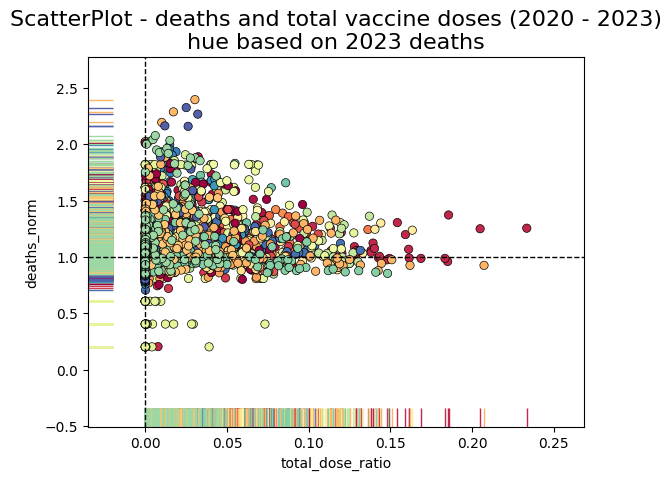

```python
temp = md.copy()
temp = temp[(temp.year >= 2020.00) & (temp.year <= 2023.999)]

temp = pd.pivot_table(
    data = temp,
    values = ['deaths_norm','total_dose_ratio'],
    index = ['abbr','name','year.p'],
    # aggfunc="sum"
)
temp = temp.reset_index()
temp['hue'] = 0.0
for _, row in ddr2023.iterrows():
    temp.loc[temp.abbr == row['abbr'], 'hue'] = _

sns.scatterplot(
    data=temp,
    x="total_dose_ratio",
    y="deaths_norm",
    hue='hue',
    edgecolor="black",
    palette='Spectral',
    legend=False
    )

sns.rugplot(
    data=temp,
    x="total_dose_ratio",
    y="deaths_norm",
    height=.05,
    hue='hue',
    palette='Spectral',
    legend=False
    )

# Add a title
plt.title("ScatterPlot - deaths and total vaccine doses (2020 - 2023)\nhue based on 2023 deaths", fontsize=16)

# Add vertical and horizontal lines
plt.axvline(x=0.0, color='black', linestyle='--', linewidth=1)  # Vertical line at x=20
plt.axhline(y=1.0, color='black', linestyle='--', linewidth=1)  # Horizontal line at y=3

plt.show()
```

notes:

- this plot is a bit unfair since the vaccines were not out in 2020

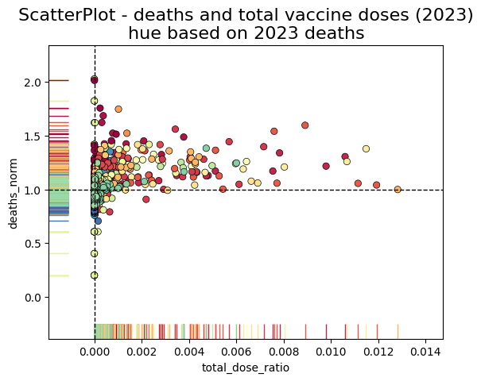

```python
temp = md.copy()
temp = temp[(temp.year >= 2023.00) & (temp.year <= 2023.999)]

temp = pd.pivot_table(
    data = temp,
    values = ['deaths_norm','total_dose_ratio'],
    index = ['abbr','name','year.p'],
    # aggfunc="sum"
)
temp = temp.reset_index()
temp['hue'] = 0.0

for _, row in ddr2023.iterrows():
    temp.loc[temp.abbr == row['abbr'], 'hue'] = _

sns.scatterplot(
    data=temp,
    x="total_dose_ratio",
    y="deaths_norm",
    hue='hue',
    edgecolor="black",
    palette='Spectral',
    legend=False
    )

sns.rugplot(
    data=temp,
    x="total_dose_ratio",
    y="deaths_norm",
    height=.05,
    hue='hue',
    palette='Spectral',
    legend=False
    )

# Add a title
plt.title("ScatterPlot - deaths and total vaccine doses (2023)\nhue based on 2023 deaths", fontsize=16)

# Add vertical and horizontal lines
plt.axvline(x=0.0, color='black', linestyle='--', linewidth=1)  # Vertical line at x=20
plt.axhline(y=1.0, color='black', linestyle='--', linewidth=1)  # Horizontal line at y=3

plt.show()
```

note:

- this plot's colors are based on the 2023 deaths
- we can see on the X axis there are fewer high deaths at the 0.0 total_dose_ratio

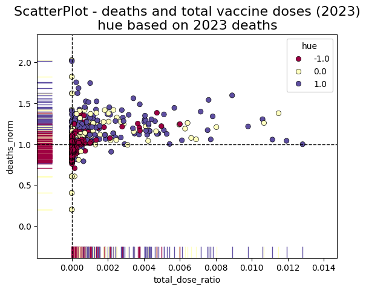

```python
temp = md.copy()
temp = temp[(temp.year >= 2023.00) & (temp.year <= 2023.999)]

temp = pd.pivot_table(
    data = temp,
    values = ['deaths_norm','total_dose_ratio'],
    index = ['abbr','name','year.p'],
    # aggfunc="sum"
)
temp = temp.reset_index()

## by powering the values it might be easier to see the correlation
#temp.deaths_norm = pow(temp.deaths_norm,2.0)
#temp.total_dose_ratio = pow(temp.total_dose_ratio,2.0)

temp['hue'] = 0.0

for n, row in ddr2023.iterrows():
    h = 0.0
    if n <= 10.0:
        h = 1.0
    if n >= 20.0:
        h = -1.0
    temp.loc[temp.abbr == row['abbr'], 'hue'] = h

sns.scatterplot(
    data=temp,
    x="total_dose_ratio",
    y="deaths_norm",
    hue='hue',
    edgecolor="black",
    palette='Spectral'
    )

sns.rugplot(
    data=temp,
    x="total_dose_ratio",
    y="deaths_norm",
    height=.05,
    hue='hue',
    palette='Spectral',
    legend=False
    )

# Add a title
plt.title("ScatterPlot - deaths and total vaccine doses (2023)\nhue based on 2023 deaths", fontsize=16)

# Add vertical and horizontal lines
plt.axvline(x=0.0, color='black', linestyle='--', linewidth=1)  # Vertical line at x=20
plt.axhline(y=1.0, color='black', linestyle='--', linewidth=1)  # Horizontal line at y=3

plt.show()
```

note:

- this plot's colors are based on the 2023 deaths, but we groupped them slow deaths, medium deaths, and high deaths
- we can see on the X axis there are fewer high deaths at the 0.0 total_dose_ratio

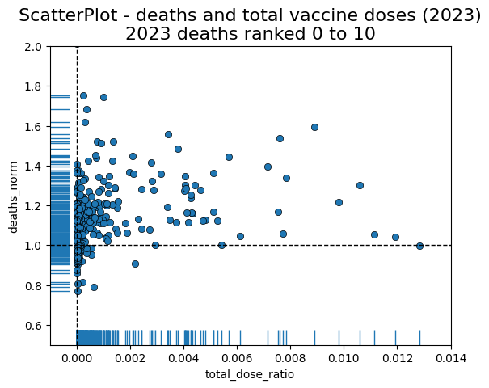

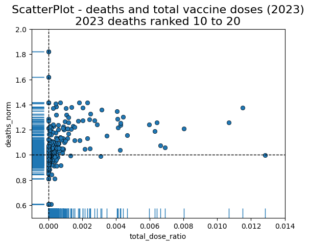

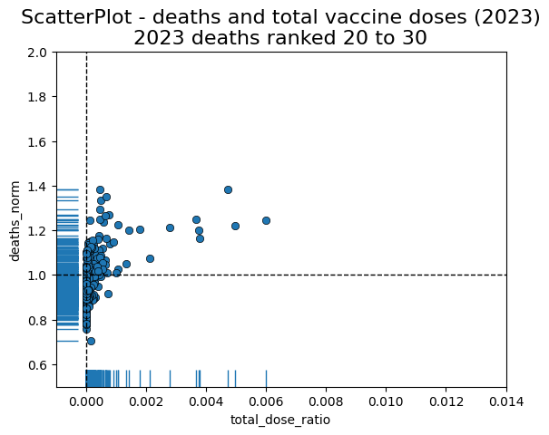

```python
temp = md.copy()
temp = temp[(temp.year >= 2023.00) & (temp.year <= 2023.999)]

temp = pd.pivot_table(
    data = temp,
    values = ['deaths_norm','total_dose_ratio'],
    index = ['abbr','name','year.p'],
    # aggfunc="sum"
)
temp = temp.reset_index()
temp['hue'] = 0.0

for _, row in ddr2023.iterrows():
    temp.loc[temp.abbr == row['abbr'], 'hue'] = _


for nums in [[0,10],[10,20],[20,30]]:

    temp2 =  temp[(temp.hue >= nums[0]) & (temp.hue <= nums[1])]

    sns.scatterplot(
        data=temp2,
        x="total_dose_ratio",
        y="deaths_norm",
        # hue='hue',
        edgecolor="black",
        # palette='Spectral',
        legend=False
        )

    sns.rugplot(
        data=temp2,
        x="total_dose_ratio",
        y="deaths_norm",
        height=.05,
        # hue='hue',
        # palette='Spectral',
        legend=False
        )

    # Add a title
    plt.title(f"ScatterPlot - deaths and total vaccine doses (2023)\n2023 deaths ranked {nums[0]} to {nums[1]}", fontsize=16)

    # Set axis ranges
    plt.xlim(- 0.001, 0.014)  # Set x-axis range from 0 to 6
    plt.ylim(0.5, 2.0) # Set y-axis range from 5 to 55

    # Add vertical and horizontal lines
    plt.axvline(x=0.0, color='black', linestyle='--', linewidth=1)  # Vertical line at x=20
    plt.axhline(y=1.0, color='black', linestyle='--', linewidth=1)  # Horizontal line at y=3

    plt.show()
```

note:

- in the plots above the death groups are broken in there own plot
- notice that the last plot much lower deaths and vaccines

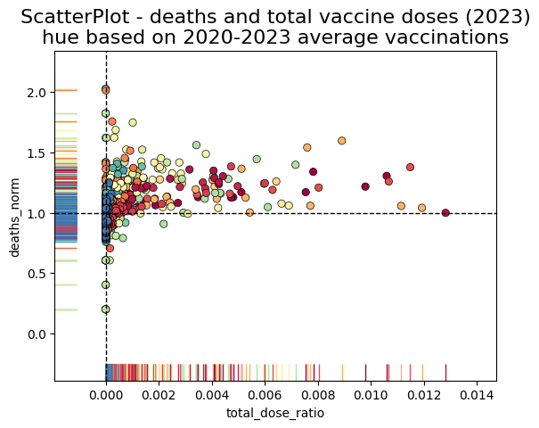

```python
temp = md.copy()
temp = temp[(temp.year >= 2023.00) & (temp.year <= 2023.999)]

temp = pd.pivot_table(
    data = temp,
    values = ['deaths_norm','total_dose_ratio'],
    index = ['abbr','name','year.p'],
    # aggfunc="sum"
)
temp = temp.reset_index()
temp['hue'] = 0.0

for _, row in vdravg.iterrows():
    temp.loc[temp.abbr == row['abbr'], 'hue'] = _

sns.scatterplot(
    data=temp,
    x="total_dose_ratio",
    y="deaths_norm",
    hue='hue',
    edgecolor="black",
    palette='Spectral',
    legend=False
    )

sns.rugplot(
    data=temp,
    x="total_dose_ratio",
    y="deaths_norm",
    height=.05,
    hue='hue',
    palette='Spectral',
    legend=False
    )

# Add a title
plt.title("ScatterPlot - deaths and total vaccine doses (2023)\nhue based on 2020-2023 average vaccinations", fontsize=16)

# Add vertical and horizontal lines
plt.axvline(x=0.0, color='black', linestyle='--', linewidth=1)  # Vertical line at x=20
plt.axhline(y=1.0, color='black', linestyle='--', linewidth=1)  # Horizontal line at y=3

# display(vdravg)
plt.show()
```

## output data

```python
ddr2023.to_csv(os.path.join(OutDIR,'ddr2023.csv'),index= False)
ddr2024.to_csv(os.path.join(OutDIR,'ddr2024.csv'),index= False)
vdr2023.to_csv(os.path.join(OutDIR,'vdr2023.csv'),index= False)
vdravg.to_csv(os.path.join(OutDIR,'vdravg.csv'),index= False)
```

## Conclusion

However this correlation is week, how can we make it stronger.

- filter out the deaths of old people (since there death might not be related to the vaccine)
- filter only by specific deaths (heart attack, stroke, and other blood and Circular Vascular related issues)

I would like to make a note of this:

- shouldn't we see the opposite correlation... where the most vaccinated countries have fewer deaths ?

## FAQs **answers contain my point of view and opinion**

- Is it possible that the deaths are not related to the vaccine?
  - yes, the correlation is low ... so it is possible that the deaths are not related to the vaccine.
  - a good experiment is repeatable, so we could
    - so if we do this with united states data, we would have the same result.
- Is there a chance that the vaccine is not working as intended?
  - the vaccine was made to save lives and to get the world back to normal faster.
  - the data does not support the claim that the "vaccine is working as intended"
- The Doctor (CDC, or other health authority) says the vaccines work as intended?
  - A doctor is a human that uses the scienific method to improve the lives and health of human beings,
    - if a doctor is not using the scientific method then they are just cosplaying.
  - Suggestion say "show me the data"

[figure not shown]

  - this question is uses the "Appeal to Authority"
    - it's a logical fallacy
      - The `insert an authority` says `statement`.
- "But I have lived through the time when vaccines saved us from Polio, Measles and SmallPox."
  - 1. this is another logical fallacy called "Straw Man"
    - the data above was clearly talking about the covid vaccine and how countries' death rates were effected over time.
  - 2. but i'll play your silly game... and there is one little thing you need to do. and that is ...

[figure not shown]

## please consider (other data)

- doing this analysis yourself with the same or similar data.
- read a book or two turtles all the way down
- read other reports/studies
  - [Pfizer's own study shows their COVID vaccines increase your risk of serious adverse events (up to 71% higher)](https://kirschsubstack.com/p/pfizers-own-study-shows-their-covid?publication_id=548354&utm_campaign=email-post-title&r=2z21oe&utm_medium=email)
    - [link to full study](https://dailysceptic.org/wp-content/uploads/2024/12/06-C4591021-interim5-report-body.pdf)
- Fork this GitHub repository [GitHub Link](https://github.com/jgarza9788/Excess_Mortality_And_Vaccines_In_Europe)
- watch/search on youtube or Rumble
  - Dr. John Campbell [Rumble](https://rumble.com/c/DrJohnCampbell) [YouTube](https://www.youtube.com/@Campbellteaching)
  - Rogue Scientist [Rumble](https://rumble.com/user/RogueScientist) [YouTube](https://www.youtube.com/@Rogue-Scientist)
  - Dr. Pierre Kory [Rumble](https://rumble.com/search/all?q=Dr.%20Pierre%20Kory) [YouTube](https://www.youtube.com/results?search_query=dr+peter+kory)
  - Dr. Robert Malone [Rumble](https://rumble.com/c/DrRobertMaloneShorts) [YouTube](https://www.youtube.com/results?search_query=dr+robert+malone)
  - Dr. Peter McCullough [Rumble](https://rumble.com/c/DrPeterMcCulloughShorts) [YouTube](https://www.youtube.com/@DrPeterMcCulloughMD)

## Part 2 is coming soon